# Alligator Event Mapping & RDF Conversion

Builds a mapping table between `rdfs:label` values and Event URIs from Alligator output files, then converts the enriched data into a full RDF graph using **CIDOC-CRM**, **GeoSPARQL**, and **OWL-Time** vocabularies.

**Pipeline**

1. Load Alligator events from a Turtle (`.ttl`) file
2. Load findspot data from a CSV file
3. Create a label-based mapping table (exact + fuzzy matching)
4. Merge mapped event data into the findspot table
5. Convert the enriched table into an RDF graph
6. Load supplementary events from `MoreEvents.csv` (OWL-Time + CIDOC-CRM nodes)
7. Build period clusters and compute Allen interval relations
8. Serialise the combined graph as Turtle
9. Generate visualisations

## 1 · Imports

```python
import sys
import shutil
from datetime import datetime
from pathlib import Path

import pandas as pd
import matplotlib

%matplotlib inline
matplotlib.use("Agg")  # keep Agg for file output; inline for display
import matplotlib.pyplot as plt
from matplotlib.ticker import AutoMinorLocator
import networkx as nx
from rdflib import Graph, Literal, Namespace, RDF, RDFS, URIRef
from rdflib.namespace import DC, XSD
from shapely.geometry import MultiPoint
from shapely import wkt as shapely_wkt


# ==============================================================================
```

## 2 · Configuration

All paths and namespace constants are centralised here. Override any value before running the pipeline cells below.

> **Note:** The notebook assumes it lives in `root/py/` (or `root/notebooks/`). Input data is expected in `root/data/`, outputs are written to `root/output/`.

```python
# override individual values in a dedicated "Configuration" cell before running
# the rest of the pipeline.

# ---------------------------------------------------------------------------
# Directory layout
# Script lives in root/py/; input data in root/data/; outputs in root/output/
# ---------------------------------------------------------------------------
SCRIPT_DIR = Path().resolve()  # notebook: use current working directory
REPO_ROOT = SCRIPT_DIR.parent
DATA_DIR = REPO_ROOT / "data"
OUTPUT_DIR = REPO_ROOT / "output"

# ---------------------------------------------------------------------------
# Input files
# ---------------------------------------------------------------------------
TTL_FILE = DATA_DIR / "ArretineDatedSitesServicesI_II.ttl"
CSV_FILE = DATA_DIR / "ArretineDatedSitesServicesI_II_findspots.csv"
MORE_EVENTS_FILE = DATA_DIR / "MoreEvents.csv"

# ---------------------------------------------------------------------------
# Namespaces – Alligator input
# ---------------------------------------------------------------------------
ALLIGATOR = Namespace("http://archaeology.link/ontology#")
AE = Namespace("http://leiza-scit.github.io/CAA2026-alligator/")

# ---------------------------------------------------------------------------
# Namespaces – RDF output
# ---------------------------------------------------------------------------
GEOSPARQL = Namespace("http://www.opengis.net/ont/geosparql#")
SF = Namespace("http://www.opengis.net/ont/sf#")
FSL = Namespace("http://fuzzy-sl.squirrel.link/ontology/")
PLEIADES_VOCAB = Namespace("https://pleiades.stoa.org/places/vocab#")
WIKIDATA = Namespace("http://www.wikidata.org/entity/")
PLEIADES_PLACE = Namespace("https://pleiades.stoa.org/places/")
LADO = Namespace("http://archaeology.link/ontology#")
CRM = Namespace("http://www.cidoc-crm.org/cidoc-crm/")
AE_SITES = Namespace("http://leiza-scit.github.io/CAA2026-alligator/")
AE_COLLECTIONS = Namespace("http://leiza-scit.github.io/CAA2026-alligator/collections/")
OWL_TIME = Namespace("http://www.w3.org/2006/time#")
SKOS = Namespace("http://www.w3.org/2004/02/skos/core#")

# ---------------------------------------------------------------------------
# Feature Collection URI
# ---------------------------------------------------------------------------
FEATURE_COLLECTION_URI = AE_COLLECTIONS["arretine_sites"]

# ---------------------------------------------------------------------------
# Known label corrections
# These fix confirmed typos in the Alligator TTL output. The mapping step
# uses the corrected labels so that TTL events match their CSV counterparts.
# Add new entries here whenever the TTL contains a label that differs from
# the authoritative CSV label.
# ---------------------------------------------------------------------------
TTL_LABEL_CORRECTIONS = {
    "Vindoniss, Militärstation": "Vindonissa, Militärstation",
    "Avences, Insula 15": "Avenches, Insula 15",
}
MAPPING_COLS = [
    "csv_label",
    "event_uri",
    "event_identifier",
    "estimatedstart",
    "estimatedend",
    "cax",
    "cay",
    "caz",
    "startfixed",
    "endfixed",
    "nfsn",
    "nfen",
]


# ==============================================================================
```

## 3 · Helper Utilities

Reusable helpers used throughout the pipeline.

- **`Logger`** — tees stdout to terminal + log file. *Not needed in a notebook;* Jupyter captures cell output natively. Kept here for completeness.
- **`sanitize_id`** — produces URI-safe identifier strings from labels.
- **rdflib gYear patch** — monkey-patches rdflib's isodate converter to handle negative (BCE) `xsd:gYear` values without raising `ISO8601Error`.
- **`_year_to_xsd_gyear`** — converts integer years to XSD gYear lexical form.

```python
class Logger:
    """Tees stdout to both the terminal and a log file simultaneously.

    Used only inside `main()` for script runs. Not needed in a notebook
    context – Jupyter captures cell output natively.
    """

    def __init__(self, filepath: Path):
        self.terminal = sys.stdout
        self.log = open(filepath, "w", encoding="utf-8")

    def write(self, message: str):
        self.terminal.write(message)
        self.log.write(message)

    def flush(self):
        self.terminal.flush()
        self.log.flush()

    def close(self):
        self.log.close()


def sanitize_id(label: str) -> str:
    """Produces a clean, URI-safe identifier string from a human-readable label."""
    id_str = label.replace(" ", "_").replace(",", "").replace("(", "").replace(")", "")
    id_str = id_str.replace("ä", "ae").replace("ö", "oe").replace("ü", "ue")
    return id_str


# rdflib delegates xsd:gYear validation to isodate, which does not handle
# negative (BCE) years and raises ISO8601Error for values like "-0015".
#
# Fix: monkey-patch rdflib.term._castLexicalToPython to intercept gYear
# calls and return the lexical string unchanged. This is more robust than
# manipulating the internal _toPythonMapping dict, whose name varies across
# rdflib versions. rdflib only uses the return value for in-memory Python
# objects; the serialised Turtle output is always taken from the lexical form
# and is therefore unaffected.
try:
    import rdflib.term as _rdflib_term

    _original_cast = _rdflib_term._castLexicalToPython  # type: ignore[attr-defined]
    _GYEAR_URI = str(XSD.gYear)

    def _patched_cast(lexical: str, datatype):  # type: ignore[no-untyped-def]
        if str(datatype) == _GYEAR_URI:
            return lexical  # Return the string as-is; isodate cannot handle BCE years
        return _original_cast(lexical, datatype)

    _rdflib_term._castLexicalToPython = _patched_cast  # type: ignore[attr-defined]
except Exception:
    pass  # Harmless if the internal API changes in a future rdflib version


def _year_to_xsd_gyear(year: int) -> str:
    """Convert an integer year to an XSD gYear lexical value.

    XSD gYear uses astronomical year numbering:
      1 BCE  →  0000
      2 BCE  → -0001
      1 CE   →  0001

    Parameters
    ----------
    year : int
        Astronomical year (negative = BCE, 0 = 1 BCE).

    Returns
    -------
    str
        Zero-padded XSD gYear string, e.g. "-0015" or "0009".
    """
    # Historian's BCE years (e.g. -15 meaning "15 BCE") are already in
    # astronomical notation in this dataset, so no offset adjustment needed.
    if year < 0:
        return f"-{abs(year):04d}"
    return f"{year:04d}"


# ==============================================================================
```

## 4 · Output Directory Setup

Clears and recreates the output directory.

> In a notebook, run this cell only when a full reset is desired.

```python
def setup_output_dir() -> Path:
    """Clears the output directory (if it exists) and recreates it fresh.

    Called once at the start of a pipeline run to ensure a clean state.
    In a notebook, run this cell only when a full reset is desired.
    """
    if OUTPUT_DIR.exists():
        shutil.rmtree(OUTPUT_DIR)
    OUTPUT_DIR.mkdir(parents=True, exist_ok=True)
    return OUTPUT_DIR


# ==============================================================================
```

```python
setup_output_dir()
print(f'Output directory ready: {OUTPUT_DIR}')
```

```
Output directory ready: C:\git\CAA2026-alligator\output
```

## 5 · Load Alligator Events (TTL)

Parses the Turtle file and extracts all `alligator:event` subjects with their associated properties. Known label typos in the TTL are corrected via `TTL_LABEL_CORRECTIONS` (Section 2).

```python
def load_alligator_events(ttl_path: Path) -> dict:
    """Load a Turtle file and extract all Alligator events with their labels.

    Parameters
    ----------
    ttl_path : Path
        Path to the Alligator output Turtle file.

    Returns
    -------
    dict
        Mapping of rdfs:label → dict of event URI and all associated properties.
    """
    print(f"Loading TTL file: {ttl_path}")

    if not ttl_path.exists():
        raise FileNotFoundError(f"TTL file not found: {ttl_path.absolute()}")

    g = Graph()
    g.parse(str(ttl_path.absolute()), format="turtle")

    events = {}

    for event_uri in g.subjects(RDF.type, ALLIGATOR.event):
        label = g.value(event_uri, RDFS.label)

        if not label:
            continue

        label_str = str(label)

        # Apply known TTL label corrections (see TTL_LABEL_CORRECTIONS in Section 2)
        label_str = TTL_LABEL_CORRECTIONS.get(label_str, label_str)

        events[label_str] = {
            "uri": str(event_uri),
            "identifier": str(
                g.value(
                    event_uri, Namespace("http://purl.org/dc/elements/1.1/").identifier
                )
                or ""
            ),
            "label": label_str,
            "estimatedstart": str(g.value(event_uri, ALLIGATOR.estimatedstart) or ""),
            "estimatedend": str(g.value(event_uri, ALLIGATOR.estimatedend) or ""),
            "cax": str(g.value(event_uri, ALLIGATOR.cax) or ""),
            "cay": str(g.value(event_uri, ALLIGATOR.cay) or ""),
            "caz": str(g.value(event_uri, ALLIGATOR.caz) or ""),
            "startfixed": str(g.value(event_uri, ALLIGATOR.startfixed) or ""),
            "endfixed": str(g.value(event_uri, ALLIGATOR.endfixed) or ""),
            "nfsn": str(g.value(event_uri, ALLIGATOR.nfsn) or ""),
            "nfen": str(g.value(event_uri, ALLIGATOR.nfen) or ""),
        }

    print(f"✓ {len(events)} events found")
    return events


# ==============================================================================
```

```python
events = load_alligator_events(TTL_FILE)
```

```
Loading TTL file: C:\git\CAA2026-alligator\data\ArretineDatedSitesServicesI_II.ttl
✓ 44 events found
```

## 6 · Load Findspot Data (CSV)

Loads the findspot CSV. Rows with inconsistent column counts are reported as warnings rather than errors.

```python
def load_findspots_csv(csv_path: Path) -> pd.DataFrame:
    """Load the findspot CSV file into a Pandas DataFrame.

    Rows with inconsistent column counts are reported as warnings rather
    than raising errors.

    Parameters
    ----------
    csv_path : Path
        Path to the findspot CSV file.

    Returns
    -------
    pd.DataFrame
        One row per findspot.
    """
    print(f"Loading CSV file: {csv_path}")

    if not csv_path.exists():
        raise FileNotFoundError(f"CSV file not found: {csv_path.absolute()}")

    df = pd.read_csv(csv_path, on_bad_lines="warn")
    print(f"✓ {len(df)} findspots loaded")
    return df


# ==============================================================================
```

```python
findspots_df = load_findspots_csv(CSV_FILE)
findspots_df.head()
```

```
Loading CSV file: C:\git\CAA2026-alligator\data\ArretineDatedSitesServicesI_II_findspots.csv
✓ 45 findspots loaded
```

|  | label | wkt | wikidata | pleiades | OSM type | OSM ID | OSM tag | OSM relation |
| --- | --- | --- | --- | --- | --- | --- | --- | --- |
| 0 | Trier-Petrisberg | POINT(6.664117 49.752021) | Q20578867 | 108894 | way | 1.048712e+08 | historic=archaeological_site | NaN |
| 1 | Nijmegen, Lager (Haalebos) | POINT(5.884209 51.839831) | Q1309708 | 98921 | NaN | NaN | NaN | NaN |
| 2 | Basel, Lager | POINT(7.593 47.5557) | Q666479 | 177468 | way | 1.683184e+08 | historic=archaeological_site | NaN |
| 3 | Vindonissa, Militärstation | POINT(8.233333 47.46667) | Q103199316 | 177661 | node | 6.420817e+09 | historic=castle | NaN |
| 4 | Neuss | POINT(6.721944 51.183889) | Q318196 | 109215 | node | 6.358516e+09 | historic=archaeological_site | NaN |

## 7 · Create Mapping Table

Matches each CSV label to a TTL event using two strategies:

- **Exact match** – label strings are identical
- **Fuzzy prefix match** – one label is a prefix of the other (e.g. `"Nijmegen, Lager"` ↔ `"Nijmegen, Lager (Haalebos)"`)

```python
def create_mapping_table(events: dict, findspots_df: pd.DataFrame) -> pd.DataFrame:
    """Build a mapping table between TTL events and CSV findspots via label matching.

    Matching strategy
    -----------------
    1. Exact match  – label strings are identical.
    2. Fuzzy match  – one label is a prefix of the other
                      (e.g. "Nijmegen, Lager" ↔ "Nijmegen, Lager (Haalebos)").

    Parameters
    ----------
    events       : dict        Output of `load_alligator_events`.
    findspots_df : pd.DataFrame Output of `load_findspots_csv`.

    Returns
    -------
    pd.DataFrame
        One row per findspot label with match type and associated event properties.
    """
    print("\nBuilding mapping table...")

    # Template for rows where no match is found
    _empty_row = dict.fromkeys(
        [
            "ttl_label",
            "event_uri",
            "event_identifier",
            "estimatedstart",
            "estimatedend",
            "cax",
            "cay",
            "caz",
            "startfixed",
            "endfixed",
            "nfsn",
            "nfen",
        ],
        None,
    )

    mapping_data = []

    for csv_label in findspots_df["label"]:
        # --- Exact match ---
        match = events.get(csv_label)
        match_type = "exact" if match else None

        # --- Fuzzy prefix match (fallback) ---
        if not match:
            for ttl_label, event_data in events.items():
                if csv_label.startswith(ttl_label) or ttl_label.startswith(csv_label):
                    match = event_data
                    match_type = "fuzzy"
                    break

        if match:
            row = {
                "csv_label": csv_label,
                "ttl_label": match["label"],
                "event_uri": match["uri"],
                "event_identifier": match["identifier"],
                "match_type": match_type,
                "estimatedstart": match["estimatedstart"],
                "estimatedend": match["estimatedend"],
                "cax": match["cax"],
                "cay": match["cay"],
                "caz": match["caz"],
                "startfixed": match["startfixed"],
                "endfixed": match["endfixed"],
                "nfsn": match["nfsn"],
                "nfen": match["nfen"],
            }
        else:
            row = {"csv_label": csv_label, "match_type": "no_match", **_empty_row}

        mapping_data.append(row)

    mapping_df = pd.DataFrame(mapping_data)

    # Summary statistics
    counts = mapping_df["match_type"].value_counts()
    print(f"\n✓ Mapping complete:")
    print(f"  Exact matches : {counts.get('exact',    0)}")
    print(f"  Fuzzy matches : {counts.get('fuzzy',    0)}")
    print(f"  No match      : {counts.get('no_match', 0)}")

    unmatched = mapping_df[mapping_df["match_type"] == "no_match"]["csv_label"].tolist()
    if unmatched:
        print(f"\n  ⚠ Unmatched findspots ({len(unmatched)}):")
        for label in unmatched:
            print(f"    · {label}")

    return mapping_df


# ==============================================================================
```

```python
mapping_df = create_mapping_table(events, findspots_df)

mapping_output = OUTPUT_DIR / "event_mapping.csv"
mapping_df.to_csv(mapping_output, index=False)
print(f"\n✓ Mapping table saved: {mapping_output}")
mapping_df.head()
```

```
Building mapping table...

✓ Mapping complete:
  Exact matches : 43
  Fuzzy matches : 1
  No match      : 1

  ⚠ Unmatched findspots (1):
    · Trier-Petrisberg

✓ Mapping table saved: C:\git\CAA2026-alligator\output\event_mapping.csv
```

|  | csv_label | match_type | ttl_label | event_uri | event_identifier | estimatedstart | estimatedend | cax | cay | caz | startfixed | endfixed | nfsn | nfen |
| --- | --- | --- | --- | --- | --- | --- | --- | --- | --- | --- | --- | --- | --- | --- |
| 0 | Trier-Petrisberg | no_match | None | None | None | None | None | None | None | None | None | None | None | None |
| 1 | Nijmegen, Lager (Haalebos) | fuzzy | Nijmegen, Lager | http://leiza-scit.github.io/CAA2026-alligator/... | vd0j5N | -16.0 | -9.0 | -1.9696 | -4.3352 | -0.6857 | false | false | Neuss | Dangstetten |
| 2 | Basel, Lager | exact | Basel, Lager | http://leiza-scit.github.io/CAA2026-alligator/... | W4XmgP | -15.0 | -9.0 | -1.2041 | -0.5444 | -0.0093 | false | false | Dangstetten | Dangstetten |
| 3 | Vindonissa, Militärstation | exact | Vindonissa, Militärstation | http://leiza-scit.github.io/CAA2026-alligator/... | N5ZEJo | -16.0 | 8.0 | -0.6857 | -0.2012 | 0.1651 | false | false | Neuss | Rödgen |
| 4 | Neuss | exact | Neuss | http://leiza-scit.github.io/CAA2026-alligator/... | OljG8l | -16.0 | 8.0 | -0.4107 | 0.0405 | -0.055 | true | false |  | Rödgen |

## 8 · Merge Findspot & Event Data

Joins mapped event properties back onto the original findspot table using the site label as the join key.

```python
def merge_findspots_and_events(
    findspots_df: pd.DataFrame,
    mapping_df: pd.DataFrame,
) -> pd.DataFrame:
    """Join mapped event properties back onto the original findspot table.

    Uses the site label as the join key. Unmatched rows retain NaN for all
    event columns (left join).

    Parameters
    ----------
    findspots_df : pd.DataFrame  Output of `load_findspots_csv`.
    mapping_df   : pd.DataFrame  Output of `create_mapping_table`.

    Returns
    -------
    pd.DataFrame
        Enriched findspot table with event columns appended.
    """
    merged_df = findspots_df.merge(
        mapping_df[MAPPING_COLS],
        left_on="label",
        right_on="csv_label",
        how="left",
    ).drop(columns="csv_label")

    return merged_df


# ==============================================================================
```

```python
merged_df = merge_findspots_and_events(findspots_df, mapping_df)

merged_output = OUTPUT_DIR / "findspots_with_events.csv"
merged_df.to_csv(merged_output, index=False)
print(f"✓ Enriched findspot table saved: {merged_output}")
merged_df.head()
```

```
✓ Enriched findspot table saved: C:\git\CAA2026-alligator\output\findspots_with_events.csv
```

|  | label | wkt | wikidata | pleiades | OSM type | OSM ID | OSM tag | OSM relation | event_uri | event_identifier | estimatedstart | estimatedend | cax | cay | caz | startfixed | endfixed | nfsn | nfen |
| --- | --- | --- | --- | --- | --- | --- | --- | --- | --- | --- | --- | --- | --- | --- | --- | --- | --- | --- | --- |
| 0 | Trier-Petrisberg | POINT(6.664117 49.752021) | Q20578867 | 108894 | way | 1.048712e+08 | historic=archaeological_site | NaN | None | None | None | None | None | None | None | None | None | None | None |
| 1 | Nijmegen, Lager (Haalebos) | POINT(5.884209 51.839831) | Q1309708 | 98921 | NaN | NaN | NaN | NaN | http://leiza-scit.github.io/CAA2026-alligator/... | vd0j5N | -16.0 | -9.0 | -1.9696 | -4.3352 | -0.6857 | false | false | Neuss | Dangstetten |
| 2 | Basel, Lager | POINT(7.593 47.5557) | Q666479 | 177468 | way | 1.683184e+08 | historic=archaeological_site | NaN | http://leiza-scit.github.io/CAA2026-alligator/... | W4XmgP | -15.0 | -9.0 | -1.2041 | -0.5444 | -0.0093 | false | false | Dangstetten | Dangstetten |
| 3 | Vindonissa, Militärstation | POINT(8.233333 47.46667) | Q103199316 | 177661 | node | 6.420817e+09 | historic=castle | NaN | http://leiza-scit.github.io/CAA2026-alligator/... | N5ZEJo | -16.0 | 8.0 | -0.6857 | -0.2012 | 0.1651 | false | false | Neuss | Rödgen |
| 4 | Neuss | POINT(6.721944 51.183889) | Q318196 | 109215 | node | 6.358516e+09 | historic=archaeological_site | NaN | http://leiza-scit.github.io/CAA2026-alligator/... | OljG8l | -16.0 | 8.0 | -0.4107 | 0.0405 | -0.055 | true | false |  | Rödgen |

## 9 · RDF Graph Utilities

Helper functions for building the RDF graph:

- **`create_rdf_graph`** – initialises a new graph with all namespace bindings
- **`add_site_to_graph`** – adds a single findspot with all its properties (types, label, geometry, Wikidata, Pleiades, OSM, Alligator temporal data, OWL-Time interval)
- **`create_feature_collection`** – declares a GeoSPARQL `FeatureCollection`

```python
def create_rdf_graph() -> Graph:
    """Create a new RDF graph with all required namespace bindings."""
    g = Graph()
    g.bind("geosparql", GEOSPARQL)
    g.bind("sf", SF)
    g.bind("fsl", FSL)
    g.bind("pleiades", PLEIADES_VOCAB)
    g.bind("wikidata", WIKIDATA)
    g.bind("pleiadesplace", PLEIADES_PLACE)
    g.bind("lado", LADO)
    g.bind("crm", CRM)
    g.bind("ae", AE_SITES)
    g.bind("aecol", AE_COLLECTIONS)
    g.bind("rdfs", RDFS)
    g.bind("time", OWL_TIME)
    g.bind("lado", LADO)
    g.bind("skos", SKOS)
    return g


def add_site_to_graph(
    g: Graph,
    row: pd.Series,
    site_uri: URIRef,
    has_event: bool = False,
):
    """Add a single findspot to the RDF graph.

    Parameters
    ----------
    g         : Graph    RDF graph to write into.
    row       : Series   DataFrame row containing site data.
    site_uri  : URIRef   URI for the site (Alligator event URI or fallback).
    has_event : bool     Whether this site has a matched Alligator event.
    """
    # --- Type assertions ---
    g.add((site_uri, RDF.type, CRM.E53_Place))
    g.add((site_uri, RDF.type, FSL.Site))
    g.add((site_uri, RDF.type, FSL.ArchaeologicalSite))
    g.add((site_uri, RDF.type, PLEIADES_VOCAB.Place))

    if has_event:
        g.add((site_uri, RDF.type, ALLIGATOR.event))
        g.add((site_uri, RDF.type, URIRef("http://www.w3.org/2006/time#Interval")))

    # --- Label ---
    g.add((site_uri, RDFS.label, Literal(row["label"], lang="en")))

    # --- DC identifier (events only) ---
    if (
        has_event
        and pd.notna(row.get("event_identifier"))
        and str(row["event_identifier"]).strip()
    ):
        g.add((site_uri, DC.identifier, Literal(row["event_identifier"])))

    # --- GeoSPARQL geometry ---
    if pd.notna(row["wkt"]) and row["wkt"].strip():
        geom_uri = URIRef(str(site_uri) + "_geom")
        wkt_literal = Literal(
            f"<http://www.opengis.net/def/crs/EPSG/0/4326> {row['wkt'].strip()}",
            datatype=GEOSPARQL.wktLiteral,
        )
        g.add((site_uri, GEOSPARQL.hasGeometry, geom_uri))
        g.add((geom_uri, RDF.type, SF.Point))
        g.add((geom_uri, GEOSPARQL.asWKT, wkt_literal))
        g.add(
            (
                geom_uri,
                FSL.certaintyDesc,
                Literal("Mapping done by Allard Mees.", lang="en"),
            )
        )

    # --- Wikidata link ---
    if pd.notna(row["wikidata"]):
        wikidata_id = str(row["wikidata"]).strip()
        if wikidata_id.startswith("Q") and wikidata_id[1:].isdigit():
            g.add((site_uri, LADO.wikidata, WIKIDATA[wikidata_id]))
        elif wikidata_id:
            print(
                f"  ⚠ Invalid Wikidata ID ignored: '{wikidata_id}' for {row['label']}"
            )

    # --- Pleiades link ---
    if pd.notna(row["pleiades"]):
        try:
            pleiades_id = (
                str(int(row["pleiades"]))
                if isinstance(row["pleiades"], (int, float))
                else str(row["pleiades"]).strip()
            )
            if pleiades_id and pleiades_id.isdigit():
                g.add((site_uri, LADO.pleiades, PLEIADES_PLACE[pleiades_id]))
            elif pleiades_id:
                print(
                    f"  ⚠ Invalid Pleiades ID ignored: '{pleiades_id}' for {row['label']}"
                )
        except (ValueError, TypeError):
            print(f"  ⚠ Pleiades ID conversion error for {row['label']}")

    # --- OpenStreetMap link ---
    # OSM type (node/way/relation) + ID → URI: http://openstreetmap.org/[type]/[id]
    # OSM tag  → lado:osm_tag  "[key=value]"
    # OSM relation (SKOS match type) → skos:exactMatch / skos:closeMatch /
    #                                   skos:relatedMatch on the OSM entity URI
    osm_type = (
        str(row.get("OSM type", "")).strip() if pd.notna(row.get("OSM type")) else ""
    )
    osm_id = row.get("OSM ID")
    osm_tag = (
        str(row.get("OSM tag", "")).strip() if pd.notna(row.get("OSM tag")) else ""
    )
    osm_rel = (
        str(row.get("OSM relation", "")).strip()
        if pd.notna(row.get("OSM relation"))
        else ""
    )

    if osm_type and pd.notna(osm_id):
        try:
            osm_id_int = int(osm_id)
            osm_uri = URIRef(f"http://openstreetmap.org/{osm_type}/{osm_id_int}")
            g.add((site_uri, LADO.osm_entity, osm_uri))

            if osm_tag:
                g.add((site_uri, LADO.osm_tag, Literal(osm_tag)))

            # Map OSM relation value to SKOS property
            _SKOS_MAP = {
                "exactMatch": SKOS.exactMatch,
                "closeMatch": SKOS.closeMatch,
                "relatedMatch": SKOS.relatedMatch,
            }
            if osm_rel in _SKOS_MAP:
                g.add((site_uri, _SKOS_MAP[osm_rel], osm_uri))
        except (ValueError, TypeError):
            print(f"  ⚠ Invalid OSM ID ignored: '{osm_id}' for {row['label']}")

    # --- Alligator temporal data (lado vocabulary, kept for compatibility) ---
    if pd.notna(row.get("estimatedstart")):
        g.add(
            (
                site_uri,
                ALLIGATOR.estimatedstart,
                Literal(row["estimatedstart"], datatype=XSD.decimal),
            )
        )
    if pd.notna(row.get("estimatedend")):
        g.add(
            (
                site_uri,
                ALLIGATOR.estimatedend,
                Literal(row["estimatedend"], datatype=XSD.decimal),
            )
        )

    # --- OWL-Time Interval pattern (only for Alligator events with temporal data) ---
    # Mirrors the lado:estimatedstart/end values as a standards-compliant
    # time:Interval with reified time:Instant nodes carrying xsd:gYear literals.
    # The estimatedstart/end values are Alligator's centroid years (decimals);
    # we round to the nearest integer for the gYear representation.
    if has_event:
        has_start = pd.notna(row.get("estimatedstart"))
        has_end = pd.notna(row.get("estimatedend"))

        if has_start or has_end:
            g.add((site_uri, RDF.type, OWL_TIME.Interval))

        if has_start:
            begin_uri = URIRef(str(site_uri) + "_begin")
            g.add((site_uri, OWL_TIME.hasBeginning, begin_uri))
            g.add((begin_uri, RDF.type, OWL_TIME.Instant))
            g.add(
                (
                    begin_uri,
                    OWL_TIME.inXSDgYear,
                    Literal(
                        _year_to_xsd_gyear(round(float(row["estimatedstart"]))),
                        datatype=XSD.gYear,
                    ),
                )
            )

        if has_end:
            end_uri = URIRef(str(site_uri) + "_end")
            g.add((site_uri, OWL_TIME.hasEnd, end_uri))
            g.add((end_uri, RDF.type, OWL_TIME.Instant))
            g.add(
                (
                    end_uri,
                    OWL_TIME.inXSDgYear,
                    Literal(
                        _year_to_xsd_gyear(round(float(row["estimatedend"]))),
                        datatype=XSD.gYear,
                    ),
                )
            )

    # --- Alligator coordinates (cax / cay / caz) ---
    for coord in ("cax", "cay", "caz"):
        if pd.notna(row.get(coord)) and str(row[coord]).strip():
            g.add(
                (site_uri, ALLIGATOR[coord], Literal(row[coord], datatype=XSD.decimal))
            )

    # --- Alligator fixed flags ---
    for flag in ("startfixed", "endfixed"):
        if pd.notna(row.get(flag)) and str(row[flag]).strip():
            g.add((site_uri, ALLIGATOR[flag], Literal(row[flag], datatype=XSD.boolean)))

    # --- Alligator neighbourhood properties ---
    for prop in ("nfsn", "nfen"):
        if pd.notna(row.get(prop)) and str(row[prop]).strip():
            g.add((site_uri, ALLIGATOR[prop], Literal(row[prop])))


def create_feature_collection(g: Graph, site_uris: list):
    """Declare a GeoSPARQL FeatureCollection and link all site URIs to it.

    GeoSPARQL supports both directions of the membership relationship,
    so both geosparql:memberOf and geosparql:hasFeature are asserted.
    """
    g.add((FEATURE_COLLECTION_URI, RDF.type, GEOSPARQL.FeatureCollection))
    g.add(
        (
            FEATURE_COLLECTION_URI,
            RDFS.label,
            Literal("Arretine Dated Sites Collection", lang="en"),
        )
    )
    g.add(
        (
            FEATURE_COLLECTION_URI,
            RDFS.comment,
            Literal(
                "Collection of archaeological sites with Arretine pottery finds",
                lang="en",
            ),
        )
    )

    for site_uri in site_uris:
        g.add((site_uri, GEOSPARQL.memberOf, FEATURE_COLLECTION_URI))
        g.add((FEATURE_COLLECTION_URI, GEOSPARQL.hasFeature, site_uri))

    print(f"✓ FeatureCollection created with {len(site_uris)} features")


# ==============================================================================
```

## 10 · RDF Conversion

Converts the enriched findspot DataFrame into an RDF graph. Sites with a matched Alligator event reuse the event URI directly; unmatched sites receive a fallback URI derived from their label.

```python
def convert_to_rdf(merged_df: pd.DataFrame) -> Graph:
    """Convert the enriched findspot DataFrame into an RDF graph.

    Sites with a matched Alligator event reuse the event URI directly.
    Unmatched sites receive a fallback URI derived from their label.

    Parameters
    ----------
    merged_df : pd.DataFrame  Output of `merge_findspots_and_events`.

    Returns
    -------
    Graph
        The populated rdflib Graph object (also serialised to disk as Turtle).
    """
    print("\n" + "=" * 60)
    print("RDF Conversion")
    print("=" * 60)

    g = create_rdf_graph()
    site_uris = []
    sites_with_events = 0
    sites_without_events = 0

    for _, row in merged_df.iterrows():
        event_uri_str = str(row.get("event_uri", "")).strip()

        if (
            pd.notna(row.get("event_uri"))
            and event_uri_str
            and event_uri_str.lower() != "nan"
        ):
            # Use the Alligator event URI directly
            site_uri = URIRef(event_uri_str)
            has_event = True
            sites_with_events += 1
        else:
            # Generate a fallback URI from the site label
            site_uri = AE_SITES[f"site_{sanitize_id(row['label'])}"]
            has_event = False
            sites_without_events += 1

        site_uris.append(site_uri)
        add_site_to_graph(g, row, site_uri, has_event)

    print(f"\n✓ {len(site_uris)} sites added to graph")
    print(f"  With event URI : {sites_with_events}")
    print(f"  Fallback URI   : {sites_without_events}")

    create_feature_collection(g, site_uris)

    # Serialise as Turtle
    output_file = OUTPUT_DIR / "arretine_sites_minigraph.ttl"
    g.serialize(destination=str(output_file), format="turtle")
    print(f"\n✓ RDF graph saved: {output_file}")
    print(f"\nGraph statistics:")
    print(f"  Triples total      : {len(g)}")
    print(f"  Sites              : {len(site_uris)}")
    print(f"  FeatureCollections : 1")

    return g


# ==============================================================================
```

```python
rdf_graph = convert_to_rdf(merged_df)
```

```
============================================================
RDF Conversion
============================================================

✓ 45 sites added to graph
  With event URI : 44
  Fallback URI   : 1
✓ FeatureCollection created with 45 features

✓ RDF graph saved: C:\git\CAA2026-alligator\output\arretine_sites_minigraph.ttl

Graph statistics:
  Triples total      : 1442
  Sites              : 45
  FeatureCollections : 1
```

## 11 · Load Supplementary Events (MoreEvents.csv)

Loads historically significant events (e.g. military campaigns) that are not part of the Alligator findspot pipeline. Each event carries a label, start year, and end year (negative = BCE).

```python
# not part of the Alligator findspot pipeline but should appear in the same RDF
# graph as temporal context. Each row carries a label, a start year, and an end
# year (negative values = BCE).


def load_more_events(csv_path: Path) -> pd.DataFrame:
    """Load the supplementary events CSV into a Pandas DataFrame.

    Expected columns
    ----------------
    label : str   Human-readable event name.
    start : int   Start year (negative = BCE).
    end   : int   End year   (negative = BCE).

    Parameters
    ----------
    csv_path : Path
        Path to MoreEvents.csv.

    Returns
    -------
    pd.DataFrame
        One row per event, with whitespace stripped from the label column.
    """
    print(f"Loading additional events: {csv_path}")

    if not csv_path.exists():
        raise FileNotFoundError(f"MoreEvents file not found: {csv_path.absolute()}")

    df = pd.read_csv(csv_path)

    # Strip accidental whitespace from the start/end columns (e.g. "- 9" → "-9")
    df["start"] = pd.to_numeric(
        df["start"].astype(str).str.replace(r"\s+", "", regex=True), errors="coerce"
    )
    df["end"] = pd.to_numeric(
        df["end"].astype(str).str.replace(r"\s+", "", regex=True), errors="coerce"
    )
    df["label"] = df["label"].str.strip()

    print(f"✓ {len(df)} additional events loaded")
    return df


# ==============================================================================
```

```python
more_events_df = load_more_events(MORE_EVENTS_FILE)
more_events_df
```

```
Loading additional events: C:\git\CAA2026-alligator\data\MoreEvents.csv
✓ 4 additional events loaded
```

|  | label | start | end |
| --- | --- | --- | --- |
| 0 | Tiberian campaign | -15 | -15 |
| 1 | Drusus campaigns | -12 | -9 |
| 2 | Clades Variana | 9 | 9 |
| 3 | Germanicus campaigns | 14 | 16 |

## 12 · Add MoreEvents to the RDF Graph

Each supplementary event is typed as `crm:E7_Activity` (CIDOC-CRM intentional activity) and `time:Interval` (OWL-Time), with reified `time:Instant` nodes carrying `time:inXSDgYear` literals for start and end.

```python
# -----------------
# Each event is typed as:
#   crm:E7_Activity   – CIDOC-CRM class for intentional human activities
#                       (campaigns are goal-directed, so E7 is preferred over
#                        the more abstract E5_Event)
#   time:Interval     – OWL-Time interval to carry temporal boundaries
#
# Temporal boundaries use the OWL-Time reified pattern:
#   <event>  time:hasBeginning  <event_begin>
#   <event>  time:hasEnd        <event_end>
#   <event_begin/end>  rdf:type          time:Instant
#   <event_begin/end>  time:inXSDgYear   "YYYY"^^xsd:gYear
#
# xsd:gYear uses the proleptic Gregorian calendar. Negative years are
# serialised as "-0014" (note: XSD gYear uses astronomical year numbering,
# so 1 BCE = 0000, 2 BCE = -0001, etc.).
# The rdflib patch and _year_to_xsd_gyear helper are defined in Section 3
# so they are available to both this section and add_site_to_graph (Section 9).


def add_more_events_to_graph(g: Graph, more_events_df: pd.DataFrame) -> list:
    """Add supplementary events from MoreEvents.csv to an existing RDF graph.

    Each event receives:
    - rdf:type  crm:E7_Activity  (CIDOC-CRM intentional activity)
    - rdf:type  time:Interval    (OWL-Time temporal interval)
    - rdfs:label
    - time:hasBeginning / time:hasEnd  →  reified time:Instant nodes
      with time:inXSDgYear literals

    Parameters
    ----------
    g               : Graph        The graph to write into (modified in place).
    more_events_df  : pd.DataFrame Output of `load_more_events`.

    Returns
    -------
    list
        URIRefs of all event nodes added.
    """
    print("\nAdding supplementary events to graph...")

    event_uris = []

    for _, row in more_events_df.iterrows():
        event_id = sanitize_id(row["label"])
        event_uri = AE_SITES[f"event_{event_id}"]
        event_uris.append(event_uri)

        # --- Type assertions ---
        g.add((event_uri, RDF.type, CRM.E7_Activity))  # CIDOC-CRM: intentional activity
        g.add((event_uri, RDF.type, OWL_TIME.Interval))  # OWL-Time: temporal interval

        # --- Label ---
        g.add((event_uri, RDFS.label, Literal(row["label"], lang="en")))

        # --- Temporal boundaries (OWL-Time reified pattern) ---
        if pd.notna(row["start"]):
            begin_uri = URIRef(str(event_uri) + "_begin")
            g.add((event_uri, OWL_TIME.hasBeginning, begin_uri))
            g.add((begin_uri, RDF.type, OWL_TIME.Instant))
            g.add(
                (
                    begin_uri,
                    OWL_TIME.inXSDgYear,
                    Literal(_year_to_xsd_gyear(int(row["start"])), datatype=XSD.gYear),
                )
            )

        if pd.notna(row["end"]):
            end_uri = URIRef(str(event_uri) + "_end")
            g.add((event_uri, OWL_TIME.hasEnd, end_uri))
            g.add((end_uri, RDF.type, OWL_TIME.Instant))
            g.add(
                (
                    end_uri,
                    OWL_TIME.inXSDgYear,
                    Literal(_year_to_xsd_gyear(int(row["end"])), datatype=XSD.gYear),
                )
            )

    print(f"✓ {len(event_uris)} supplementary events added to graph")
    return event_uris


# ==============================================================================
```

```python
add_more_events_to_graph(rdf_graph, more_events_df)
```

```
Adding supplementary events to graph...
✓ 4 supplementary events added to graph
```

```
[rdflib.term.URIRef('http://leiza-scit.github.io/CAA2026-alligator/event_Tiberian_campaign'),
 rdflib.term.URIRef('http://leiza-scit.github.io/CAA2026-alligator/event_Drusus_campaigns'),
 rdflib.term.URIRef('http://leiza-scit.github.io/CAA2026-alligator/event_Clades_Variana'),
 rdflib.term.URIRef('http://leiza-scit.github.io/CAA2026-alligator/event_Germanicus_campaigns')]
```

## 13 · Period Cluster Detection

Groups Alligator events into `lado:PeriodCluster` nodes when their `estimatedstart` AND `estimatedend` values are exactly equal.

Each cluster receives:

- `lado:PeriodCluster` + `time:Interval` with OWL-Time begin/end instants
- `lado:hasClusterMember` → each member event URI
- `geosparql:FeatureCollection` membership
- A ConvexHull geometry (`sf:Point` / `sf:LineString` / `sf:Polygon`) computed from member site coordinates via Shapely

```python
# estimatedstart AND estimatedend values are exactly equal (no tolerance).
# This reflects the nearest-neighbour logic of the Alligator algorithm:
# identical boundaries are never coincidental — they are the same period.
#
# Each cluster is modelled as:
#   lado:PeriodCluster  – new LADO class for a group of co-dated events
#   time:Interval       – OWL-Time interval with begin/end Instants
#   lado:hasClusterMember → each member event URI
#   geosparql:hasGeometry → a sf:Polygon ConvexHull of all member points
#   geosparql:FeatureCollection → all member site URIs


def build_period_clusters(
    events: dict,
    g: Graph,
) -> list[dict]:
    """Group Alligator events into PeriodClusters by identical start/end values.

    Uses the events dict loaded directly from the TTL (all 44 events).
    WKT geometries are looked up directly from the RDF graph via event URI,
    which is robust against label spelling discrepancies between TTL and CSV.

    Parameters
    ----------
    events : dict   Output of `load_alligator_events` (label → event data).
    g      : Graph  RDF graph already populated by `convert_to_rdf`.

    Returns
    -------
    list[dict]
        One dict per cluster, sorted by start year, with keys:
            start   – shared estimatedstart value (float)
            end     – shared estimatedend value (float)
            members – list of dicts: event_uri, label, wkt
    """
    print("\nDetecting period clusters...")

    # WKT lookup: directly from the graph via event URI → hasGeometry → asWKT.
    # Fallback: search by rdfs:label in case the site was written as a fallback
    # URI (i.e. not matched to an Alligator event URI during the mapping step).
    # This handles TTL label typos like "Vindoniss" vs "Vindonissa".
    def _get_wkt(event_uri: str, label: str) -> str | None:
        # 1. Try via event URI directly
        uri_ref = URIRef(event_uri)
        for geom_uri in g.objects(uri_ref, GEOSPARQL.hasGeometry):
            wkt_lit = g.value(geom_uri, GEOSPARQL.asWKT)
            if wkt_lit:
                raw = str(wkt_lit)
                return raw.split("> ", 1)[-1] if "> " in raw else raw
        # 2. Fallback: find any node in the graph with a matching rdfs:label
        for subj in g.subjects(RDFS.label, Literal(label, lang="en")):
            for geom_uri in g.objects(subj, GEOSPARQL.hasGeometry):
                wkt_lit = g.value(geom_uri, GEOSPARQL.asWKT)
                if wkt_lit:
                    raw = str(wkt_lit)
                    return raw.split("> ", 1)[-1] if "> " in raw else raw
        return None

    # --- Group by (estimatedstart, estimatedend) — exact match only ---
    from collections import defaultdict

    groups = defaultdict(list)

    for label, event in events.items():
        start_str = event.get("estimatedstart", "").strip()
        end_str = event.get("estimatedend", "").strip()
        if not start_str or not end_str:
            continue
        try:
            start = float(start_str)
            end = float(end_str)
        except ValueError:
            continue

        groups[(start, end)].append(
            {
                "event_uri": event["uri"],
                "label": label,
                "wkt": _get_wkt(event["uri"], label),
            }
        )

    clusters = [
        {"start": start, "end": end, "members": members}
        for (start, end), members in sorted(groups.items())
    ]

    print(f"✓ {len(clusters)} period clusters detected")
    for c in clusters:
        missing_wkt = [m["label"] for m in c["members"] if not m["wkt"]]
        print(
            f"  [{c['start']:>8.1f} – {c['end']:>8.1f}]  "
            f"{len(c['members']):2d} member(s): "
            f"{[m['label'] for m in c['members']]}"
        )
        if missing_wkt:
            print(f"    ⚠ No WKT for: {missing_wkt}")

    return clusters


def _build_convex_hull_wkt(wkt_list: list) -> tuple[str, str] | tuple[None, None]:
    """Compute the convex hull from a list of WKT Point strings using Shapely.

    Returns a (wkt, sf_type) pair where sf_type is the appropriate
    Simple Features class name for the rdflib graph:
      1 point  → sf:Point
      2 points → sf:LineString
      3+points → sf:Polygon  (true convex hull)

    Parameters
    ----------
    wkt_list : list
        WKT strings, e.g. ["POINT(8.5 51.2)", ...]. None values are skipped.

    Returns
    -------
    tuple[str, str] | tuple[None, None]
        (wkt_string, sf_type_name) or (None, None) if no valid points found.
    """
    points = []
    for wkt_str in wkt_list:
        if not wkt_str:
            continue
        try:
            geom = shapely_wkt.loads(wkt_str)
            points.append((geom.x, geom.y))
        except Exception:
            pass  # Skip malformed WKT

    if not points:
        return None, None

    hull = MultiPoint(points).convex_hull  # Point / LineString / Polygon
    geom_type = hull.geom_type  # "Point", "LineString", or "Polygon"
    return hull.wkt, geom_type


def add_period_clusters_to_graph(g: Graph, clusters: list) -> list:
    """Add PeriodCluster nodes to the RDF graph.

    Each cluster receives:
    - rdf:type  lado:PeriodCluster
    - rdf:type  time:Interval
    - rdfs:label  (auto-generated from year range)
    - time:hasBeginning / time:hasEnd  →  time:Instant with time:inXSDgYear
    - lado:hasClusterMember  →  each member event URI
    - geosparql:hasGeometry  →  sf:Polygon ConvexHull of member points
    - geosparql:FeatureCollection membership (bidirectional)

    Parameters
    ----------
    g        : Graph   RDF graph to write into.
    clusters : list    Output of `build_period_clusters`.

    Returns
    -------
    list
        URIRefs of all PeriodCluster nodes added (in cluster order).
    """
    print("\nAdding period clusters to graph...")

    cluster_uris = []

    for idx, cluster in enumerate(clusters):
        start_yr = round(cluster["start"])
        end_yr = round(cluster["end"])

        # URI uses zero-padded years; bc/ad prefix for readability
        start_str = f"{'bc' if start_yr < 0 else 'ad'}{abs(start_yr):04d}"
        end_str = f"{'bc' if end_yr   < 0 else 'ad'}{abs(end_yr):04d}"
        cluster_uri = AE_COLLECTIONS[f"cluster_{start_str}_{end_str}"]
        cluster_uris.append(cluster_uri)

        # --- Type assertions ---
        g.add((cluster_uri, RDF.type, LADO.PeriodCluster))
        g.add((cluster_uri, RDF.type, OWL_TIME.Interval))
        g.add((cluster_uri, RDF.type, GEOSPARQL.FeatureCollection))

        # --- Label ---
        label_str = (
            f"Period cluster {start_yr} – {end_yr} CE"
            if start_yr >= 0
            else f"Period cluster {abs(start_yr)} BCE – "
            + (f"{abs(end_yr)} BCE" if end_yr < 0 else f"{end_yr} CE")
        )
        g.add((cluster_uri, RDFS.label, Literal(label_str, lang="en")))

        # --- OWL-Time temporal boundaries ---
        begin_uri = URIRef(str(cluster_uri) + "_begin")
        end_uri = URIRef(str(cluster_uri) + "_end")

        g.add((cluster_uri, OWL_TIME.hasBeginning, begin_uri))
        g.add((begin_uri, RDF.type, OWL_TIME.Instant))
        g.add(
            (
                begin_uri,
                OWL_TIME.inXSDgYear,
                Literal(_year_to_xsd_gyear(start_yr), datatype=XSD.gYear),
            )
        )

        g.add((cluster_uri, OWL_TIME.hasEnd, end_uri))
        g.add((end_uri, RDF.type, OWL_TIME.Instant))
        g.add(
            (
                end_uri,
                OWL_TIME.inXSDgYear,
                Literal(_year_to_xsd_gyear(end_yr), datatype=XSD.gYear),
            )
        )

        # --- Member links + FeatureCollection membership ---
        wkt_list = []
        for member in cluster["members"]:
            member_uri = URIRef(member["event_uri"])
            g.add((cluster_uri, LADO.hasClusterMember, member_uri))
            g.add((cluster_uri, GEOSPARQL.hasFeature, member_uri))
            g.add((member_uri, GEOSPARQL.memberOf, cluster_uri))
            if member["wkt"]:
                wkt_list.append(member["wkt"])

        # --- ConvexHull geometry (Point / LineString / Polygon) ---
        hull_wkt, sf_type = _build_convex_hull_wkt(wkt_list)
        if hull_wkt and sf_type:
            geom_uri = URIRef(str(cluster_uri) + "_geom")
            wkt_literal = Literal(
                f"<http://www.opengis.net/def/crs/EPSG/0/4326> {hull_wkt}",
                datatype=GEOSPARQL.wktLiteral,
            )
            sf_class = URIRef(
                str(SF) + sf_type
            )  # sf:Point / sf:LineString / sf:Polygon
            g.add((cluster_uri, GEOSPARQL.hasGeometry, geom_uri))
            g.add((geom_uri, RDF.type, sf_class))
            g.add((geom_uri, GEOSPARQL.asWKT, wkt_literal))
        else:
            print(f"  ⚠ No geometry available for: {label_str}")

    print(f"✓ {len(cluster_uris)} period clusters added to graph")
    return cluster_uris


# ==============================================================================
```

```python
clusters     = build_period_clusters(events, rdf_graph)
cluster_uris = add_period_clusters_to_graph(rdf_graph, clusters)
```

```
Detecting period clusters...
✓ 10 period clusters detected
  [   -16.0 –     -9.0]   2 member(s): ['Nijmegen, Lager', 'Zürich, Lindenhof']
  [   -16.0 –      8.0]   4 member(s): ['Vindonissa, Militärstation', 'Neuss', 'Asberg, Lager', 'Liberchies']
  [   -16.0 –      9.0]   3 member(s): ['Basel, Lagerdorf', 'Lausanne-Vidy', 'Augsburg-Oberhausen']
  [   -16.0 –     13.0]   1 member(s): ['Worms']
  [   -15.0 –     -9.0]   3 member(s): ['Basel, Lager', 'Dangstetten', 'Titelberg']
  [   -12.0 –      8.0]   2 member(s): ['Rödgen', 'Namur']
  [   -11.0 –      8.0]   1 member(s): ['Oberaden']
  [    -7.0 –      9.0]  12 member(s): ['Conimbriga', 'Tongeren', 'Bonn, Boeselagerhof', 'Nijmegen, Lager (Brunsting)', 'Vetera I', 'Bad Nauheim', 'Haltern', 'Asberg, Lagerdorf', 'Braives', 'Lorenzberg', 'Mainz, Legionslager', 'Vindonissa, Scheuerhof']
  [     7.0 –     13.0]  10 member(s): ['Augst, Insula 31', 'Bregenz', 'Nijmegen, Trajanusplein', 'Nijmegen, Valkhof', 'Augsburg, Stadt', 'Avenches, Insula 15', 'Friedberg', 'Oberwinterthur, Römerstr. 186', 'Vindonissa, Königsfelden', 'Wiesbaden']
  [    16.0 –     28.0]   6 member(s): ['Augst, Insula 20', 'Vechten', 'Augst, Theater', 'Maastricht', 'Velsen', 'Zurzach, Lager']

Adding period clusters to graph...
✓ 10 period clusters added to graph
```

## 14 · Allen's Interval Relations Between Clusters

Computes all 13 Allen interval relations between every pair of `PeriodCluster` nodes and writes them explicitly as `time:interval*` triples. Both directions are written so queries work from either subject.

| Relation | OWL-Time property |
| --- | --- |
| precedes | `time:intervalBefore` |
| meets | `time:intervalMeets` |
| overlaps | `time:intervalOverlaps` |
| finished-by | `time:intervalFinishedBy` |
| contains | `time:intervalContains` |
| starts | `time:intervalStarts` |
| equals | `time:intervalEquals` |
| … | … |

```python
# intervals. OWL-Time implements all 13 as object properties on time:Interval.
# This section computes the applicable relation(s) for every ordered pair of
# PeriodClusters and writes them explicitly into the graph.
#
# All 13 Allen relations and their OWL-Time properties:
#
#   Relation        OWL-Time property          Condition (s=start, e=end)
#   ─────────────────────────────────────────────────────────────────────
#   precedes        time:intervalBefore         A.end  <  B.start
#   meets           time:intervalMeets          A.end  == B.start
#   overlaps        time:intervalOverlaps       A.start < B.start < A.end < B.end
#   finished-by     time:intervalFinishedBy     A.start < B.start, A.end == B.end
#   contains        time:intervalContains       A.start < B.start, A.end > B.end
#   starts          time:intervalStarts         A.start == B.start, A.end < B.end
#   equals          time:intervalEquals         A.start == B.start, A.end == B.end
#   started-by      time:intervalStartedBy      A.start == B.start, A.end > B.end
#   during          time:intervalDuring         A.start > B.start, A.end < B.end
#   finishes        time:intervalFinishes       A.start > B.start, A.end == B.end
#   overlapped-by   time:intervalOverlappedBy   B.start < A.start < B.end < A.end
#   met-by          time:intervalMetBy          B.end  == A.start
#   preceded-by     time:intervalAfter          B.end  <  A.start
#
# Note: equals is symmetric; the other 12 come in inverse pairs. We write
# both directions explicitly so queries work regardless of which subject is used.


def _allen_relations(
    a_start: float, a_end: float, b_start: float, b_end: float
) -> list:
    """Return the list of OWL-Time Allen relation properties that hold between
    interval A [a_start, a_end] and interval B [b_start, b_end].

    Returns
    -------
    list of URIRef
        OWL-Time property URIs for the applicable Allen relation(s).
    """
    relations = []

    if a_end < b_start:
        relations.append(OWL_TIME.intervalBefore)
    elif a_end == b_start:
        relations.append(OWL_TIME.intervalMeets)
    elif a_start < b_start and b_start < a_end and a_end < b_end:
        relations.append(OWL_TIME.intervalOverlaps)
    elif a_start < b_start and a_end == b_end:
        relations.append(OWL_TIME.intervalFinishedBy)
    elif a_start < b_start and a_end > b_end:
        relations.append(OWL_TIME.intervalContains)
    elif a_start == b_start and a_end < b_end:
        relations.append(OWL_TIME.intervalStarts)
    elif a_start == b_start and a_end == b_end:
        relations.append(OWL_TIME.intervalEquals)
    elif a_start == b_start and a_end > b_end:
        relations.append(OWL_TIME.intervalStartedBy)
    elif a_start > b_start and a_end < b_end:
        relations.append(OWL_TIME.intervalDuring)
    elif a_start > b_start and a_end == b_end:
        relations.append(OWL_TIME.intervalFinishes)
    elif b_start < a_start and a_start < b_end and b_end < a_end:
        relations.append(OWL_TIME.intervalOverlappedBy)
    elif b_end == a_start:
        relations.append(OWL_TIME.intervalMetBy)
    elif b_end < a_start:
        relations.append(OWL_TIME.intervalAfter)

    return relations


def add_allen_relations_to_graph(
    g: Graph,
    clusters: list,
    cluster_uris: list,
) -> int:
    """Compute and write all Allen interval relations between PeriodClusters.

    Iterates over every ordered pair (A, B) of clusters and asserts the
    applicable OWL-Time Allen relation triple(s). Both directions are written
    explicitly (A → B and B → A) so queries work from either subject.

    Parameters
    ----------
    g            : Graph  RDF graph to write into.
    clusters     : list   Output of `build_period_clusters`.
    cluster_uris : list   Output of `add_period_clusters_to_graph` (same order).

    Returns
    -------
    int
        Total number of Allen relation triples written.
    """
    print("\nComputing Allen interval relations between clusters...")

    triple_count = 0

    for i in range(len(clusters)):
        for j in range(len(clusters)):
            if i == j:
                continue

            a_uri = cluster_uris[i]
            b_uri = cluster_uris[j]
            a_start = clusters[i]["start"]
            a_end = clusters[i]["end"]
            b_start = clusters[j]["start"]
            b_end = clusters[j]["end"]

            for rel in _allen_relations(a_start, a_end, b_start, b_end):
                g.add((a_uri, rel, b_uri))
                triple_count += 1

    print(
        f"✓ {triple_count} Allen relation triples written across "
        f"{len(clusters)} clusters"
    )
    return triple_count


# ==============================================================================
# SECTION 16 · Visualisations
# ==============================================================================
# Produces JPEG figures saved to OUTPUT_DIR.
# All plot functions are self-contained: they take only plain Python data
# structures (no rdflib objects) so they can be called independently in a
# notebook without re-running the full RDF pipeline.


def _format_year_label(year: float) -> str:
    """Return a human-readable year label, e.g. '15 BC' or 'AD 9'."""
    y = round(year)
    return f"{abs(y)} BC" if y < 0 else f"AD {y}"


def plot_cluster_timeline(clusters: list, output_path: Path):
    """Draw a horizontal timeline showing all PeriodClusters as labelled bars.

    Each cluster is rendered as a horizontal bar spanning [start, end].
    Clusters are sorted by start year (earliest at top) and stacked
    vertically. Member count and year range are shown inside / beside
    each bar. A colour gradient encodes the number of members.

    Parameters
    ----------
    clusters    : list   Output of `build_period_clusters`.
    output_path : Path   Destination JPEG file.
    """
    if not clusters:
        print("  ⚠ No clusters to plot — skipping timeline.")
        return

    # Sort earliest-start first (top of chart)
    sorted_clusters = sorted(clusters, key=lambda c: c["start"])
    n = len(sorted_clusters)
```

```python
    # --- Figure layout ---
    fig_h = max(4, n * 0.65 + 2)
    fig, ax = plt.subplots(figsize=(14, fig_h))
    fig.patch.set_facecolor("white")
    ax.set_facecolor("#f7f7f7")

    # Colour map: member count → colour intensity
    max_members = max(len(c["members"]) for c in sorted_clusters)
    cmap = plt.get_cmap("YlOrRd")

    bar_height = 0.55
    y_positions = list(range(n))

    for i, cluster in enumerate(sorted_clusters):
        y = y_positions[i]
        start = cluster["start"]
        end = cluster["end"]
        duration = end - start if end != start else 0.5  # point-in-time: thin bar
        n_members = len(cluster["members"])

        colour = cmap(0.3 + 0.7 * (n_members / max_members))

        # Bar
        ax.barh(
            y,
            duration,
            left=start,
            height=bar_height,
            color=colour,
            edgecolor="#00000022",
            linewidth=0.5,
            align="center",
        )

        # Year range label inside bar (if wide enough) or to the right
        range_label = f"{_format_year_label(start)} – {_format_year_label(end)}"
        member_label = f"  {n_members} site{'s' if n_members != 1 else ''}"
        bar_centre = start + duration / 2

        # Text inside bar
        ax.text(
            bar_centre,
            y,
            range_label,
            ha="center",
            va="center",
            fontsize=7.5,
            color="white",
            fontweight="bold",
            clip_on=True,
        )

        # Member count to the right of bar
        ax.text(
            end + 0.3,
            y,
            member_label,
            ha="left",
            va="center",
            fontsize=7.5,
            color="#333333",
        )

    # --- Axes styling ---
    all_starts = [c["start"] for c in sorted_clusters]
    all_ends = [c["end"] for c in sorted_clusters]
    x_min = min(all_starts) - 3
    x_max = max(all_ends) + 8

    ax.set_xlim(x_min, x_max)
    ax.set_ylim(-0.8, n - 0.2)
    ax.set_yticks([])

    # X-axis: convert to BC/AD labels
    x_ticks = [t for t in range(int(x_min), int(x_max) + 1, 5)]
    ax.set_xticks(x_ticks)
    ax.set_xticklabels(
        [_format_year_label(t) for t in x_ticks],
        rotation=45,
        ha="right",
        fontsize=8,
        color="#333333",
    )
    ax.xaxis.set_minor_locator(AutoMinorLocator(5))
    ax.tick_params(axis="x", which="minor", length=3, color="#aaaaaa")
    ax.tick_params(axis="x", which="major", length=6, color="#888888")

    # Grid lines — only subtle ticks on x-axis, no vertical lines through bars
    ax.set_axisbelow(True)
    ax.grid(axis="x", which="major", color="#dddddd", linewidth=0.5, zorder=0)
    ax.grid(axis="x", which="minor", visible=False)

    # Spine styling
    for spine in ax.spines.values():
        spine.set_edgecolor("#cccccc")

    # Colorbar gradient legend (continuous, not discrete patches)
    sm = plt.cm.ScalarMappable(cmap=cmap, norm=plt.Normalize(vmin=1, vmax=max_members))
    sm.set_array([])
    cbar = fig.colorbar(
        sm, ax=ax, orientation="vertical", fraction=0.02, pad=0.02, aspect=20
    )
    cbar.set_label("Number of sites", fontsize=8, color="#333333")
    cbar.ax.yaxis.set_tick_params(color="#333333", labelsize=7)
    plt.setp(cbar.ax.yaxis.get_ticklabels(), color="#333333")

    ax.set_title(
        "Alligator Period Clusters — Timeline",
        color="#111111",
        fontsize=13,
        fontweight="bold",
        pad=12,
    )
    ax.set_xlabel("Year", color="#333333", fontsize=9)

    plt.tight_layout()
    fig.savefig(
        str(output_path),
        dpi=150,
        format="jpeg",
        bbox_inches="tight",
        facecolor=fig.get_facecolor(),
    )
    plt.close(fig)
    print(f"✓ Timeline saved: {output_path}")


def plot_alligator_events_timeline(events: dict, output_path: Path):
    """Draw a timeline of individual Alligator events, styled after the JS tool.

    Colour coding
    -------------
    - Gold   (#f0a500) : event with startfixed=false OR endfixed=false
                         (Alligator-calculated boundaries)
    - Steel  (#8fa8c8) : event with startfixed=true AND endfixed=true
                         (both boundaries are fixed/certain)

    Label format (inside bar, as in the JS tool)
    --------------------------------------------
    - Fixed both ends  : "label"
    - Unfixed start    : "nfsn-->label,label"  (nfsn = nearest-fixed start neighbour)
    - Unfixed end      : "label-->nfen,label"  (nfen = nearest-fixed end neighbour)
    - Unfixed both     : "nfsn-->nfen,label"

    Parameters
    ----------
    events      : dict   Output of `load_alligator_events`.
    output_path : Path   Destination JPEG file.
    """
    if not events:
        print("  ⚠ No events to plot — skipping Alligator timeline.")
        return

    # --- Collect and sort events by estimatedstart, then estimatedend ---
    rows = []
    for label, ev in events.items():
        try:
            start = float(ev["estimatedstart"])
            end = float(ev["estimatedend"])
        except (ValueError, TypeError):
            continue

        start_fixed = ev.get("startfixed", "").strip().lower() == "true"
        end_fixed = ev.get("endfixed", "").strip().lower() == "true"
        nfsn = ev.get("nfsn", "").strip()
        nfen = ev.get("nfen", "").strip()

        # Build label string matching JS tool format:
        # label-->nfsn,nfen  (both unfixed)
        # label-->*,nfen     (start fixed, end unfixed)
        # label-->nfsn,*     (start unfixed, end fixed)
        # label              (both fixed — shown in blue/steel)
        if start_fixed and end_fixed:
            bar_label = label
        elif start_fixed and not end_fixed:
            bar_label = f"{label}-->*,{nfen}" if nfen else label
        elif not start_fixed and end_fixed:
            bar_label = f"{label}-->{nfsn},*" if nfsn else label
        else:  # both unfixed
            bar_label = f"{label}-->{nfsn},{nfen}" if nfsn and nfen else label
```

```python
        rows.append(
            {
                "label": label,
                "bar_label": bar_label,
                "start": start,
                "end": end,
                "both_fixed": start_fixed and end_fixed,
            }
        )

    # Sort: primary by estimatedstart, secondary by estimatedend, tertiary by label
    # This groups events by cluster period, matching the JS tool's visual grouping
    rows.sort(key=lambda r: (r["start"], r["end"], r["label"]))
    n = len(rows)

    # --- Colours matching the JS tool ---
    COLOUR_CALC = "#f0a500"  # gold   — calculated (unfixed) boundaries
    COLOUR_FIXED = "#8fa8c8"  # steel  — both boundaries fixed
    TEXT_COLOUR = "#1a1a1a"  # dark label text

    bar_height = 0.55
    fig_h = max(6, n * 0.42 + 2)
    fig, ax = plt.subplots(figsize=(16, fig_h))
    fig.patch.set_facecolor("white")
    ax.set_facecolor("white")

    for i, row in enumerate(rows):
        duration = row["end"] - row["start"] if row["end"] != row["start"] else 0.3
        colour = COLOUR_FIXED if row["both_fixed"] else COLOUR_CALC

        ax.barh(
            i,
            duration,
            left=row["start"],
            height=bar_height,
            color=colour,
            edgecolor="#00000018",
            linewidth=0.4,
            align="center",
        )

        # Label inside bar — clip so it never overflows
        bar_centre = row["start"] + duration / 2
        ax.text(
            bar_centre,
            i,
            row["bar_label"],
            ha="center",
            va="center",
            fontsize=6.5,
            color=TEXT_COLOUR,
            clip_on=True,
            fontfamily="monospace",
        )

        # Draw a subtle separator line between cluster groups
        if i > 0 and (
            rows[i]["start"] != rows[i - 1]["start"]
            or rows[i]["end"] != rows[i - 1]["end"]
        ):
            ax.axhline(
                i - 0.5, color="#cccccc", linewidth=0.6, linestyle="--", zorder=1
            )

    # --- Axes ---
    all_starts = [r["start"] for r in rows]
    all_ends = [r["end"] for r in rows]
    x_min = min(all_starts) - 2
    x_max = max(all_ends) + 2

    ax.set_xlim(x_min, x_max)
    ax.set_ylim(-0.8, n - 0.2)
    ax.set_yticks([])

    x_ticks = list(range(int(x_min), int(x_max) + 1, 5))
    ax.set_xticks(x_ticks)
    ax.set_xticklabels(
        [_format_year_label(t) for t in x_ticks],
        rotation=45,
        ha="right",
        fontsize=8,
        color="#333333",
    )
    ax.xaxis.set_minor_locator(AutoMinorLocator(5))
    ax.tick_params(axis="x", which="minor", length=2, color="#cccccc")
    ax.tick_params(axis="x", which="major", length=5, color="#aaaaaa")

    ax.grid(axis="x", which="major", color="#eeeeee", linewidth=0.5, zorder=0)
    ax.set_axisbelow(True)

    for spine in ax.spines.values():
        spine.set_edgecolor("#cccccc")

    # --- Legend ---
    import matplotlib.patches as mpatches

    legend_patches = [
        mpatches.Patch(color=COLOUR_CALC, label="Calculated boundaries (nfsn / nfen)"),
        mpatches.Patch(
            color=COLOUR_FIXED, label="Fixed boundaries (startfixed & endfixed)"
        ),
    ]
    ax.legend(
        handles=legend_patches,
        loc="lower right",
        fontsize=8,
        framealpha=0.9,
        facecolor="white",
        edgecolor="#cccccc",
    )

    ax.set_title(
        "Alligator Events — Individual Site Timeline",
        color="#111111",
        fontsize=13,
        fontweight="bold",
        pad=12,
    )
    ax.set_xlabel("Year", color="#333333", fontsize=9)

    plt.tight_layout()
    fig.savefig(
        str(output_path), dpi=150, format="jpeg", bbox_inches="tight", facecolor="white"
    )
    plt.close(fig)
    print(f"✓ Events timeline saved: {output_path}")


def plot_allen_relations_matrix(clusters: list, output_path: Path):
    """Draw a matrix visualisation of all Allen interval relations between clusters.

    Each cell (row A, col B) shows the Allen relation that holds between
    cluster A and cluster B. Cells are colour-coded by relation family:

      Sequential  (blue)   : before, after, meets, metBy
      Overlapping (orange) : overlaps, overlappedBy
      Containing  (red)    : contains, during, starts, startedBy,
                             finishes, finishedBy
      Equal       (green)  : equals

    The relation abbreviation is printed inside each cell.

    Parameters
    ----------
    clusters    : list   Output of `build_period_clusters`.
    output_path : Path   Destination JPEG file.
    """
    if not clusters:
        print("  ⚠ No clusters to plot — skipping Allen matrix.")
        return

    # --- Relation metadata: OWL-Time local name → (abbreviation, colour family) ---
    RELATIONS = {
        "intervalBefore": ("before", "#4a90d9"),  # blue
        "intervalAfter": ("after", "#2c5f8a"),  # dark blue
        "intervalMeets": ("meets", "#7ab3e0"),  # light blue
        "intervalMetBy": ("met-by", "#5a9fc5"),  # mid blue
        "intervalOverlaps": ("overlaps", "#f0a500"),  # orange
        "intervalOverlappedBy": ("ovlp-by", "#c97d00"),  # dark orange
        "intervalContains": ("contains", "#d94a4a"),  # red
        "intervalDuring": ("during", "#a03030"),  # dark red
        "intervalStarts": ("starts", "#e07070"),  # light red
        "intervalStartedBy": ("started-by", "#c05050"),  # mid red
        "intervalFinishes": ("finishes", "#e09090"),  # pink-red
        "intervalFinishedBy": ("finished-by", "#b04060"),  # rose
        "intervalEquals": ("equals", "#4caf50"),  # green
    }

    n = len(clusters)

    # Build short axis labels from year range
    def _cluster_label(c: dict) -> str:
        s = round(c["start"])
        e = round(c["end"])
        sl = f"{abs(s)}BC" if s < 0 else f"AD{s}"
        el = f"{abs(e)}BC" if e < 0 else f"AD{e}"
        return f"{sl}–{el}"

    labels = [_cluster_label(c) for c in clusters]

    # Pre-compute Allen relations for every ordered pair
    cell_data = {}  # (i, j) → (abbrev, colour)
    for i, ca in enumerate(clusters):
        for j, cb in enumerate(clusters):
            if i == j:
                continue
            rels = _allen_relations(ca["start"], ca["end"], cb["start"], cb["end"])
            if rels:
                # Extract local name from URIRef, e.g. "...#intervalBefore"
                rel_local = str(rels[0]).split("#")[-1]
                if rel_local in RELATIONS:
                    abbrev, colour = RELATIONS[rel_local]
                    cell_data[(i, j)] = (abbrev, colour)
```

```python
    # --- Figure ---
    cell_size = 1.1
    fig_size = max(8, n * cell_size + 2)
    fig, ax = plt.subplots(figsize=(fig_size, fig_size))
    fig.patch.set_facecolor("white")
    ax.set_facecolor("#f9f9f9")

    # Draw cells
    for (i, j), (abbrev, colour) in cell_data.items():
        # i = row (A), j = col (B)  — matrix origin top-left
        rect = plt.Rectangle(
            [j, n - i - 1], 1, 1, facecolor=colour, edgecolor="white", linewidth=1.5
        )
        ax.add_patch(rect)
        ax.text(
            j + 0.5,
            n - i - 0.5,
            abbrev,
            ha="center",
            va="center",
            fontsize=7,
            color="white",
            fontweight="bold",
        )

    # Diagonal — same cluster, no relation
    for k in range(n):
        rect = plt.Rectangle(
            [k, n - k - 1], 1, 1, facecolor="#dddddd", edgecolor="white", linewidth=1.5
        )
        ax.add_patch(rect)
        ax.text(
            k + 0.5,
            n - k - 0.5,
            "—",
            ha="center",
            va="center",
            fontsize=8,
            color="#999999",
        )

    # Axes
    ax.set_xlim(0, n)
    ax.set_ylim(0, n)
    ax.set_xticks([i + 0.5 for i in range(n)])
    ax.set_yticks([i + 0.5 for i in range(n)])
    ax.set_xticklabels(labels, rotation=45, ha="left", fontsize=8)
    ax.set_yticklabels(list(reversed(labels)), fontsize=8)
    ax.xaxis.set_ticks_position("top")
    ax.xaxis.set_label_position("top")
    ax.tick_params(length=0)

    for spine in ax.spines.values():
        spine.set_visible(False)

    # --- Legend ---
    import matplotlib.patches as mpatches

    legend_items = [
        mpatches.Patch(
            color="#4a90d9", label="Sequential (before / after / meets / met-by)"
        ),
        mpatches.Patch(color="#f0a500", label="Overlapping (overlaps / overlapped-by)"),
        mpatches.Patch(
            color="#d94a4a",
            label="Containing (contains / during / starts / finishes …)",
        ),
        mpatches.Patch(color="#4caf50", label="Equal"),
        mpatches.Patch(color="#dddddd", label="Same cluster"),
    ]
    ax.legend(
        handles=legend_items,
        loc="lower right",
        bbox_to_anchor=(1.0, -0.22),
        fontsize=8,
        framealpha=0.9,
        facecolor="white",
        edgecolor="#cccccc",
        ncol=2,
    )

    ax.set_title(
        "Allen Interval Relations Between Period Clusters",
        color="#111111",
        fontsize=13,
        fontweight="bold",
        pad=28,
    )

    ax.set_xlabel("Cluster B  (column)", color="#555555", fontsize=9, labelpad=8)
    ax.set_ylabel("Cluster A  (row)", color="#555555", fontsize=9, labelpad=8)

    plt.tight_layout()
    fig.savefig(
        str(output_path), dpi=150, format="jpeg", bbox_inches="tight", facecolor="white"
    )
    plt.close(fig)
    print(f"✓ Allen matrix saved: {output_path}")


def plot_allen_chain(clusters: list, output_path: Path):
    """Draw a directed graph showing only the nearest Allen relation per cluster.

    For each cluster, only the single most immediate relation to its nearest
    temporal neighbour in each direction (earlier / later) is shown. This
    produces a clean chain rather than a fully-connected graph.

    Relation priority (most specific wins):
      meets > overlaps > contains/during/starts/finishes > before

    Parameters
    ----------
    clusters    : list   Output of `build_period_clusters`.
    output_path : Path   Destination JPEG file.
    """
    if not clusters:
        print("  ⚠ No clusters to plot — skipping Allen chain.")
        return

    # Relation metadata
    REL_STYLE = {
        "intervalMeets": ("#4a90d9", "-", 2.2, "meets"),
        "intervalOverlaps": ("#f0a500", "--", 2.0, "overlaps"),
        "intervalOverlappedBy": ("#c97d00", "--", 2.0, "ovlp-by"),
        "intervalContains": ("#d94a4a", ":", 1.8, "contains"),
        "intervalDuring": ("#a03030", ":", 1.8, "during"),
        "intervalStarts": ("#e07070", ":", 1.6, "starts"),
        "intervalStartedBy": ("#c05050", ":", 1.6, "started-by"),
        "intervalFinishes": ("#e09090", ":", 1.6, "finishes"),
        "intervalFinishedBy": ("#b04060", ":", 1.6, "finished-by"),
        "intervalBefore": ("#aaaaaa", "-", 1.2, "before"),
        "intervalAfter": ("#aaaaaa", "-", 1.2, "after"),
    }

    # Priority: lower = more specific / interesting
    REL_PRIORITY = {
        "intervalMeets": 0,
        "intervalOverlaps": 1,
        "intervalOverlappedBy": 1,
        "intervalStartedBy": 2,
        "intervalStarts": 2,
        "intervalFinishedBy": 2,
        "intervalFinishes": 2,
        "intervalContains": 3,
        "intervalDuring": 3,
        "intervalBefore": 4,  # fallback — keeps isolated nodes connected
        "intervalAfter": 4,
    }

    def _short_label(c: dict) -> str:
        s = round(c["start"])
        e = round(c["end"])
        sl = f"{abs(s)}BC" if s < 0 else f"AD{s}"
        el = f"{abs(e)}BC" if e < 0 else f"AD{e}"
        return f"{sl}–{el}"

    n = len(clusters)
    max_members = max(len(c["members"]) for c in clusters)

    # --- For each cluster, find the single best relation to each other cluster
    #     but only keep the nearest neighbour in each direction (by midpoint) ---
    def _midpoint(c):
        return (c["start"] + c["end"]) / 2

    # Build candidate edges: (i → j, rel_local) keeping only best priority
    best_edge = {}  # (i, j) → (rel_local, priority)
    for i, ca in enumerate(clusters):
        for j, cb in enumerate(clusters):
            if i == j:
                continue
            rels = _allen_relations(ca["start"], ca["end"], cb["start"], cb["end"])
            for rel_uri in rels:
                rel_local = str(rel_uri).split("#")[-1]
                if rel_local not in REL_PRIORITY:
                    continue
                prio = REL_PRIORITY[rel_local]
                if (i, j) not in best_edge or prio < best_edge[(i, j)][1]:
                    best_edge[(i, j)] = (rel_local, prio)
```

```python
    # For each cluster keep only the single nearest neighbour in each direction
    # Use a generous search radius so no cluster stays isolated
    kept_edges = set()
    for i, ca in enumerate(clusters):
        mid_i = _midpoint(ca)

        # All earlier neighbours (no distance cutoff — always connect to nearest)
        earlier = [
            (j, _midpoint(clusters[j]))
            for j in range(n)
            if j != i and _midpoint(clusters[j]) < mid_i and (i, j) in best_edge
        ]
        if earlier:
            nearest_j = max(earlier, key=lambda x: x[1])[0]
            kept_edges.add((i, nearest_j))

        # All later neighbours
        later = [
            (j, _midpoint(clusters[j]))
            for j in range(n)
            if j != i and _midpoint(clusters[j]) > mid_i and (i, j) in best_edge
        ]
        if later:
            nearest_j = min(later, key=lambda x: x[1])[0]
            kept_edges.add((i, nearest_j))

    # --- Build graph ---
    G = nx.DiGraph()
    G.add_nodes_from(range(n))
    for i, j in kept_edges:
        rel_local, _ = best_edge[(i, j)]
        G.add_edge(i, j, rel=rel_local)

    # --- Node positions ---
    # X = temporal midpoint on time axis
    # Y = rank within clusters sharing similar midpoints, staggered to avoid overlap
    # Sort clusters by midpoint for consistent ranking
    sorted_idx = sorted(
        range(n),
        key=lambda i: (
            _midpoint(clusters[i]),
            clusters[i]["end"] - clusters[i]["start"],
        ),
    )

    # Assign Y by grouping clusters with similar midpoints into lanes
    pos = {}
    lane_width = 3.0  # year units — clusters within this range share a lane group
    lanes: list[list[int]] = []
    for i in sorted_idx:
        mid = _midpoint(clusters[i])
        placed = False
        for lane in lanes:
            if abs(_midpoint(clusters[lane[0]]) - mid) < lane_width:
                lane.append(i)
                placed = True
                break
        if not placed:
            lanes.append([i])

    # Within each lane group, spread nodes vertically
    y_spread = 8.0
    for lane in lanes:
        x_mid = _midpoint(clusters[lane[0]])
        if len(lane) == 1:
            pos[lane[0]] = (x_mid, 0)
        else:
            for k, idx in enumerate(lane):
                y = (k - (len(lane) - 1) / 2) * (y_spread / max(len(lane) - 1, 1))
                pos[idx] = (x_mid, y)

    node_labels = {i: _short_label(clusters[i]) for i in range(n)}
    cmap = plt.get_cmap("YlOrRd")
    node_colours = [
        cmap(0.3 + 0.7 * len(clusters[i]["members"]) / max_members) for i in range(n)
    ]
    node_sizes = [800 + 250 * len(clusters[i]["members"]) for i in range(n)]

    # --- Figure ---
    fig, ax = plt.subplots(figsize=(16, 8))
    fig.patch.set_facecolor("white")
    ax.set_facecolor("#f9f9f9")

    # Nodes
    nx.draw_networkx_nodes(
        G,
        pos,
        ax=ax,
        node_color=node_colours,
        node_size=node_sizes,
        edgecolors="#333333",
        linewidths=0.8,
    )
    nx.draw_networkx_labels(
        G,
        pos,
        labels=node_labels,
        ax=ax,
        font_size=7.5,
        font_color="#111111",
        font_weight="bold",
    )

    # Edges — draw each separately to respect individual styles, no labels
    for i, j in G.edges():
        rel_local = G[i][j]["rel"]
        colour, ls, lw, _ = REL_STYLE.get(rel_local, ("#888888", "-", 1.5, rel_local))

        nx.draw_networkx_edges(
            G,
            pos,
            edgelist=[(i, j)],
            ax=ax,
            edge_color=[colour],
            width=lw,
            style=ls,
            arrows=True,
            arrowsize=18,
            arrowstyle="-|>",
            connectionstyle="arc3,rad=0.15",
            min_source_margin=24,
            min_target_margin=24,
        )

    # --- Axes ---
    all_starts = [c["start"] for c in clusters]
    all_ends = [c["end"] for c in clusters]
    x_min = min(all_starts) - 3
    x_max = max(all_ends) + 3
    ax.set_xlim(x_min, x_max)
    x_ticks = list(range(int(x_min), int(x_max) + 1, 5))
    ax.set_xticks(x_ticks)
    ax.set_xticklabels(
        [_format_year_label(t) for t in x_ticks],
        rotation=45,
        ha="right",
        fontsize=8,
        color="#333333",
    )
    ax.set_yticks([])
    ax.grid(axis="x", color="#dddddd", linewidth=0.5, zorder=0)
    ax.set_axisbelow(True)
    for spine in ax.spines.values():
        spine.set_edgecolor("#cccccc")

    # --- Legend ---
    import matplotlib.lines as mlines

    legend_items = [
        mlines.Line2D(
            [], [], color="#4a90d9", linewidth=2.2, linestyle="-", label="meets"
        ),
        mlines.Line2D(
            [],
            [],
            color="#f0a500",
            linewidth=2.0,
            linestyle="--",
            label="overlaps / overlapped-by",
        ),
        mlines.Line2D(
            [],
            [],
            color="#d94a4a",
            linewidth=1.8,
            linestyle=":",
            label="contains / during / starts / finishes …",
        ),
        mlines.Line2D(
            [],
            [],
            color="#aaaaaa",
            linewidth=1.2,
            linestyle="-",
            label="before / after (nearest only)",
        ),
    ]
    ax.legend(
        handles=legend_items,
        loc="lower right",
        fontsize=8,
        framealpha=0.9,
        facecolor="white",
        edgecolor="#cccccc",
    )

    ax.set_title(
        "Allen Interval Relations — Nearest-Neighbour Chain",
        color="#111111",
        fontsize=13,
        fontweight="bold",
        pad=12,
    )

    plt.tight_layout()
    fig.savefig(
        str(output_path), dpi=150, format="jpeg", bbox_inches="tight", facecolor="white"
    )
    plt.close(fig)
    print(f"✓ Allen chain saved: {output_path}")


# ==============================================================================
# SECTION 17 · Main Entry Point
# ==============================================================================
# When converting to a notebook, replace this function with one cell per step.
# The Logger/sys.stdout redirect is intentionally confined here and should be
# omitted in a notebook (Jupyter handles cell output natively).
```

```python
def main():
    """Run the full pipeline end to end."""
    setup_output_dir()

    log_file = OUTPUT_DIR / "report.txt"
    logger = Logger(log_file)
    sys.stdout = logger

    try:
        print("=" * 60)
        print("Alligator Event Mapping")
        print(f"Timestamp: {datetime.now().strftime('%Y-%m-%d %H:%M:%S')}")
        print("=" * 60)

        # Step 1 – Load TTL events
        events = load_alligator_events(TTL_FILE)

        # Step 2 – Load findspot CSV
        findspots_df = load_findspots_csv(CSV_FILE)

        # Step 3 – Build mapping table
        mapping_df = create_mapping_table(events, findspots_df)

        # Step 4 – Save mapping table
        mapping_output = OUTPUT_DIR / "event_mapping.csv"
        mapping_df.to_csv(mapping_output, index=False)
        print(f"\n✓ Mapping table saved: {mapping_output}")

        # Step 5 – Merge findspot + event data
        merged_df = merge_findspots_and_events(findspots_df, mapping_df)
        merged_output = OUTPUT_DIR / "findspots_with_events.csv"
        merged_df.to_csv(merged_output, index=False)
        print(f"✓ Enriched findspot table saved: {merged_output}")

        # Step 6 – RDF conversion of findspot data
        rdf_graph = convert_to_rdf(merged_df)

        # Step 7 – Load and integrate supplementary events (MoreEvents.csv)
        more_events_df = load_more_events(MORE_EVENTS_FILE)
        add_more_events_to_graph(rdf_graph, more_events_df)

        # Step 8 – Build period clusters directly from TTL events
        clusters = build_period_clusters(events, rdf_graph)
        cluster_uris = add_period_clusters_to_graph(rdf_graph, clusters)

        # Step 9 – Compute and write Allen interval relations between clusters
        add_allen_relations_to_graph(rdf_graph, clusters, cluster_uris)

        # Step 10 – Serialise the final combined graph
        output_file = OUTPUT_DIR / "arretine_sites_minigraph.ttl"
        rdf_graph.serialize(destination=str(output_file), format="turtle")
        print(f"\n✓ Final RDF graph saved: {output_file}")
        print(f"  Triples total: {len(rdf_graph)}")

        # Step 11 – Visualisations
        print("\n" + "=" * 60)
        print("Visualisations")
        print("=" * 60)
        plot_cluster_timeline(clusters, OUTPUT_DIR / "cluster_timeline.jpg")
        plot_alligator_events_timeline(events, OUTPUT_DIR / "events_timeline.jpg")
        plot_allen_relations_matrix(clusters, OUTPUT_DIR / "allen_matrix.jpg")
        plot_allen_chain(clusters, OUTPUT_DIR / "allen_chain.jpg")

        print("\n" + "=" * 60)
        print("Done!")
        print(f"Report saved: {log_file}")
        print("=" * 60)

    finally:
        sys.stdout = logger.terminal
        logger.close()


if __name__ == "__main__":
    main()
```

```
============================================================
Alligator Event Mapping
Timestamp: 2026-03-17 12:51:07
============================================================
Loading TTL file: C:\git\CAA2026-alligator\data\ArretineDatedSitesServicesI_II.ttl
✓ 44 events found
Loading CSV file: C:\git\CAA2026-alligator\data\ArretineDatedSitesServicesI_II_findspots.csv
✓ 45 findspots loaded

Building mapping table...

✓ Mapping complete:
  Exact matches : 43
  Fuzzy matches : 1
  No match      : 1

  ⚠ Unmatched findspots (1):
    · Trier-Petrisberg

✓ Mapping table saved: C:\git\CAA2026-alligator\output\event_mapping.csv
✓ Enriched findspot table saved: C:\git\CAA2026-alligator\output\findspots_with_events.csv

============================================================
RDF Conversion
============================================================

✓ 45 sites added to graph
  With event URI : 44
  Fallback URI   : 1
✓ FeatureCollection created with 45 features

✓ RDF graph saved: C:\git\CAA2026-alligator\output\arretine_sites_minigraph.ttl

Graph statistics:
  Triples total      : 1442
  Sites              : 45
  FeatureCollections : 1
Loading additional events: C:\git\CAA2026-alligator\data\MoreEvents.csv
✓ 4 additional events loaded

```

[output cut: 22 more lines]

```
✓ Final RDF graph saved: C:\git\CAA2026-alligator\output\arretine_sites_minigraph.ttl
  Triples total: 1830

============================================================
Visualisations
============================================================
✓ Timeline saved: C:\git\CAA2026-alligator\output\cluster_timeline.jpg
✓ Events timeline saved: C:\git\CAA2026-alligator\output\events_timeline.jpg
✓ Allen matrix saved: C:\git\CAA2026-alligator\output\allen_matrix.jpg
✓ Allen chain saved: C:\git\CAA2026-alligator\output\allen_chain.jpg

============================================================
Done!
Report saved: C:\git\CAA2026-alligator\output\report.txt
============================================================
```

```python
add_allen_relations_to_graph(rdf_graph, clusters, cluster_uris)
```

```
Computing Allen interval relations between clusters...
✓ 90 Allen relation triples written across 10 clusters
```

```
90
```

## 15 · Serialise the Final RDF Graph

Saves the complete graph as Turtle to `output/arretine_sites_minigraph.ttl`.

```python
output_file = OUTPUT_DIR / "arretine_sites_minigraph.ttl"
rdf_graph.serialize(destination=str(output_file), format="turtle")
print(f"✓ RDF graph saved: {output_file}")
print(f"  Triples total: {len(rdf_graph)}")
```

```
✓ RDF graph saved: C:\git\CAA2026-alligator\output\arretine_sites_minigraph.ttl
  Triples total: 1830
```

## 16 · Visualisations

Four JPEG figures are produced:

| File | Description |
| --- | --- |
| `cluster_timeline.jpg` | Horizontal bar chart of period clusters coloured by member count |
| `events_timeline.jpg` | Individual Alligator events styled after the JS tool (gold/steel) |
| `allen_matrix.jpg` | 10×10 matrix of all Allen relations between clusters |
| `allen_chain.jpg` | Directed graph showing nearest-neighbour Allen relations |

```python
# All plot functions are self-contained: they take only plain Python data
# structures (no rdflib objects) so they can be called independently in a
# notebook without re-running the full RDF pipeline.


def _format_year_label(year: float) -> str:
    """Return a human-readable year label, e.g. '15 BC' or 'AD 9'."""
    y = round(year)
    return f"{abs(y)} BC" if y < 0 else f"AD {y}"


def plot_cluster_timeline(clusters: list, output_path: Path):
    """Draw a horizontal timeline showing all PeriodClusters as labelled bars.

    Each cluster is rendered as a horizontal bar spanning [start, end].
    Clusters are sorted by start year (earliest at top) and stacked
    vertically. Member count and year range are shown inside / beside
    each bar. A colour gradient encodes the number of members.

    Parameters
    ----------
    clusters    : list   Output of `build_period_clusters`.
    output_path : Path   Destination JPEG file.
    """
    if not clusters:
        print("  ⚠ No clusters to plot — skipping timeline.")
        return

    # Sort earliest-start first (top of chart)
    sorted_clusters = sorted(clusters, key=lambda c: c["start"])
    n = len(sorted_clusters)

    # --- Figure layout ---
    fig_h = max(4, n * 0.65 + 2)
    fig, ax = plt.subplots(figsize=(14, fig_h))
    fig.patch.set_facecolor("white")
    ax.set_facecolor("#f7f7f7")

    # Colour map: member count → colour intensity
    max_members = max(len(c["members"]) for c in sorted_clusters)
    cmap = plt.get_cmap("YlOrRd")

    bar_height = 0.55
    y_positions = list(range(n))

    for i, cluster in enumerate(sorted_clusters):
        y = y_positions[i]
        start = cluster["start"]
        end = cluster["end"]
        duration = end - start if end != start else 0.5  # point-in-time: thin bar
        n_members = len(cluster["members"])

        colour = cmap(0.3 + 0.7 * (n_members / max_members))

        # Bar
        ax.barh(
            y,
            duration,
            left=start,
            height=bar_height,
            color=colour,
            edgecolor="#00000022",
            linewidth=0.5,
            align="center",
        )

        # Year range label inside bar (if wide enough) or to the right
        range_label = f"{_format_year_label(start)} – {_format_year_label(end)}"
        member_label = f"  {n_members} site{'s' if n_members != 1 else ''}"
        bar_centre = start + duration / 2

        # Text inside bar
        ax.text(
            bar_centre,
            y,
            range_label,
            ha="center",
            va="center",
            fontsize=7.5,
            color="white",
            fontweight="bold",
            clip_on=True,
        )

        # Member count to the right of bar
        ax.text(
            end + 0.3,
            y,
            member_label,
            ha="left",
            va="center",
            fontsize=7.5,
            color="#333333",
        )

    # --- Axes styling ---
    all_starts = [c["start"] for c in sorted_clusters]
    all_ends = [c["end"] for c in sorted_clusters]
    x_min = min(all_starts) - 3
    x_max = max(all_ends) + 8

    ax.set_xlim(x_min, x_max)
    ax.set_ylim(-0.8, n - 0.2)
    ax.set_yticks([])

    # X-axis: convert to BC/AD labels
    x_ticks = [t for t in range(int(x_min), int(x_max) + 1, 5)]
    ax.set_xticks(x_ticks)
    ax.set_xticklabels(
        [_format_year_label(t) for t in x_ticks],
        rotation=45,
        ha="right",
        fontsize=8,
        color="#333333",
    )
    ax.xaxis.set_minor_locator(AutoMinorLocator(5))
    ax.tick_params(axis="x", which="minor", length=3, color="#aaaaaa")
    ax.tick_params(axis="x", which="major", length=6, color="#888888")

    # Grid lines — only subtle ticks on x-axis, no vertical lines through bars
    ax.set_axisbelow(True)
    ax.grid(axis="x", which="major", color="#dddddd", linewidth=0.5, zorder=0)
    ax.grid(axis="x", which="minor", visible=False)

    # Spine styling
    for spine in ax.spines.values():
        spine.set_edgecolor("#cccccc")

    # Colorbar gradient legend (continuous, not discrete patches)
    sm = plt.cm.ScalarMappable(cmap=cmap, norm=plt.Normalize(vmin=1, vmax=max_members))
    sm.set_array([])
    cbar = fig.colorbar(
        sm, ax=ax, orientation="vertical", fraction=0.02, pad=0.02, aspect=20
    )
    cbar.set_label("Number of sites", fontsize=8, color="#333333")
    cbar.ax.yaxis.set_tick_params(color="#333333", labelsize=7)
    plt.setp(cbar.ax.yaxis.get_ticklabels(), color="#333333")

    ax.set_title(
        "Alligator Period Clusters — Timeline",
        color="#111111",
        fontsize=13,
        fontweight="bold",
        pad=12,
    )
    ax.set_xlabel("Year", color="#333333", fontsize=9)

    plt.tight_layout()
    fig.savefig(
        str(output_path),
        dpi=150,
        format="jpeg",
        bbox_inches="tight",
        facecolor=fig.get_facecolor(),
    )
    plt.close(fig)
    print(f"✓ Timeline saved: {output_path}")


def plot_alligator_events_timeline(events: dict, output_path: Path):
    """Draw a timeline of individual Alligator events, styled after the JS tool.

    Colour coding
    -------------
    - Gold   (#f0a500) : event with startfixed=false OR endfixed=false
                         (Alligator-calculated boundaries)
    - Steel  (#8fa8c8) : event with startfixed=true AND endfixed=true
                         (both boundaries are fixed/certain)

    Label format (inside bar, as in the JS tool)
    --------------------------------------------
    - Fixed both ends  : "label"
    - Unfixed start    : "nfsn-->label,label"  (nfsn = nearest-fixed start neighbour)
    - Unfixed end      : "label-->nfen,label"  (nfen = nearest-fixed end neighbour)
    - Unfixed both     : "nfsn-->nfen,label"

    Parameters
    ----------
    events      : dict   Output of `load_alligator_events`.
    output_path : Path   Destination JPEG file.
    """
    if not events:
        print("  ⚠ No events to plot — skipping Alligator timeline.")
        return
```

```python
    # --- Collect and sort events by estimatedstart, then estimatedend ---
    rows = []
    for label, ev in events.items():
        try:
            start = float(ev["estimatedstart"])
            end = float(ev["estimatedend"])
        except (ValueError, TypeError):
            continue

        start_fixed = ev.get("startfixed", "").strip().lower() == "true"
        end_fixed = ev.get("endfixed", "").strip().lower() == "true"
        nfsn = ev.get("nfsn", "").strip()
        nfen = ev.get("nfen", "").strip()

        # Build label string matching JS tool format:
        # label-->nfsn,nfen  (both unfixed)
        # label-->*,nfen     (start fixed, end unfixed)
        # label-->nfsn,*     (start unfixed, end fixed)
        # label              (both fixed — shown in blue/steel)
        if start_fixed and end_fixed:
            bar_label = label
        elif start_fixed and not end_fixed:
            bar_label = f"{label}-->*,{nfen}" if nfen else label
        elif not start_fixed and end_fixed:
            bar_label = f"{label}-->{nfsn},*" if nfsn else label
        else:  # both unfixed
            bar_label = f"{label}-->{nfsn},{nfen}" if nfsn and nfen else label

        rows.append(
            {
                "label": label,
                "bar_label": bar_label,
                "start": start,
                "end": end,
                "both_fixed": start_fixed and end_fixed,
            }
        )

    # Sort: primary by estimatedstart, secondary by estimatedend, tertiary by label
    # This groups events by cluster period, matching the JS tool's visual grouping
    rows.sort(key=lambda r: (r["start"], r["end"], r["label"]))
    n = len(rows)

    # --- Colours matching the JS tool ---
    COLOUR_CALC = "#f0a500"  # gold   — calculated (unfixed) boundaries
    COLOUR_FIXED = "#8fa8c8"  # steel  — both boundaries fixed
    TEXT_COLOUR = "#1a1a1a"  # dark label text

    bar_height = 0.55
    fig_h = max(6, n * 0.42 + 2)
    fig, ax = plt.subplots(figsize=(16, fig_h))
    fig.patch.set_facecolor("white")
    ax.set_facecolor("white")

    for i, row in enumerate(rows):
        duration = row["end"] - row["start"] if row["end"] != row["start"] else 0.3
        colour = COLOUR_FIXED if row["both_fixed"] else COLOUR_CALC

        ax.barh(
            i,
            duration,
            left=row["start"],
            height=bar_height,
            color=colour,
            edgecolor="#00000018",
            linewidth=0.4,
            align="center",
        )

        # Label inside bar — clip so it never overflows
        bar_centre = row["start"] + duration / 2
        ax.text(
            bar_centre,
            i,
            row["bar_label"],
            ha="center",
            va="center",
            fontsize=6.5,
            color=TEXT_COLOUR,
            clip_on=True,
            fontfamily="monospace",
        )

        # Draw a subtle separator line between cluster groups
        if i > 0 and (
            rows[i]["start"] != rows[i - 1]["start"]
            or rows[i]["end"] != rows[i - 1]["end"]
        ):
            ax.axhline(
                i - 0.5, color="#cccccc", linewidth=0.6, linestyle="--", zorder=1
            )

    # --- Axes ---
    all_starts = [r["start"] for r in rows]
    all_ends = [r["end"] for r in rows]
    x_min = min(all_starts) - 2
    x_max = max(all_ends) + 2

    ax.set_xlim(x_min, x_max)
    ax.set_ylim(-0.8, n - 0.2)
    ax.set_yticks([])

    x_ticks = list(range(int(x_min), int(x_max) + 1, 5))
    ax.set_xticks(x_ticks)
    ax.set_xticklabels(
        [_format_year_label(t) for t in x_ticks],
        rotation=45,
        ha="right",
        fontsize=8,
        color="#333333",
    )
    ax.xaxis.set_minor_locator(AutoMinorLocator(5))
    ax.tick_params(axis="x", which="minor", length=2, color="#cccccc")
    ax.tick_params(axis="x", which="major", length=5, color="#aaaaaa")

    ax.grid(axis="x", which="major", color="#eeeeee", linewidth=0.5, zorder=0)
    ax.set_axisbelow(True)

    for spine in ax.spines.values():
        spine.set_edgecolor("#cccccc")

    # --- Legend ---
    import matplotlib.patches as mpatches

    legend_patches = [
        mpatches.Patch(color=COLOUR_CALC, label="Calculated boundaries (nfsn / nfen)"),
        mpatches.Patch(
            color=COLOUR_FIXED, label="Fixed boundaries (startfixed & endfixed)"
        ),
    ]
    ax.legend(
        handles=legend_patches,
        loc="lower right",
        fontsize=8,
        framealpha=0.9,
        facecolor="white",
        edgecolor="#cccccc",
    )

    ax.set_title(
        "Alligator Events — Individual Site Timeline",
        color="#111111",
        fontsize=13,
        fontweight="bold",
        pad=12,
    )
    ax.set_xlabel("Year", color="#333333", fontsize=9)

    plt.tight_layout()
    fig.savefig(
        str(output_path), dpi=150, format="jpeg", bbox_inches="tight", facecolor="white"
    )
    plt.close(fig)
    print(f"✓ Events timeline saved: {output_path}")


def plot_allen_relations_matrix(clusters: list, output_path: Path):
    """Draw a matrix visualisation of all Allen interval relations between clusters.

    Each cell (row A, col B) shows the Allen relation that holds between
    cluster A and cluster B. Cells are colour-coded by relation family:

      Sequential  (blue)   : before, after, meets, metBy
      Overlapping (orange) : overlaps, overlappedBy
      Containing  (red)    : contains, during, starts, startedBy,
                             finishes, finishedBy
      Equal       (green)  : equals

    The relation abbreviation is printed inside each cell.

    Parameters
    ----------
    clusters    : list   Output of `build_period_clusters`.
    output_path : Path   Destination JPEG file.
    """
    if not clusters:
        print("  ⚠ No clusters to plot — skipping Allen matrix.")
        return

    # --- Relation metadata: OWL-Time local name → (abbreviation, colour family) ---
    RELATIONS = {
        "intervalBefore": ("before", "#4a90d9"),  # blue
        "intervalAfter": ("after", "#2c5f8a"),  # dark blue
        "intervalMeets": ("meets", "#7ab3e0"),  # light blue
        "intervalMetBy": ("met-by", "#5a9fc5"),  # mid blue
        "intervalOverlaps": ("overlaps", "#f0a500"),  # orange
        "intervalOverlappedBy": ("ovlp-by", "#c97d00"),  # dark orange
        "intervalContains": ("contains", "#d94a4a"),  # red
        "intervalDuring": ("during", "#a03030"),  # dark red
        "intervalStarts": ("starts", "#e07070"),  # light red
        "intervalStartedBy": ("started-by", "#c05050"),  # mid red
        "intervalFinishes": ("finishes", "#e09090"),  # pink-red
        "intervalFinishedBy": ("finished-by", "#b04060"),  # rose
        "intervalEquals": ("equals", "#4caf50"),  # green
    }
```

```python
    n = len(clusters)

    # Build short axis labels from year range
    def _cluster_label(c: dict) -> str:
        s = round(c["start"])
        e = round(c["end"])
        sl = f"{abs(s)}BC" if s < 0 else f"AD{s}"
        el = f"{abs(e)}BC" if e < 0 else f"AD{e}"
        return f"{sl}–{el}"

    labels = [_cluster_label(c) for c in clusters]

    # Pre-compute Allen relations for every ordered pair
    cell_data = {}  # (i, j) → (abbrev, colour)
    for i, ca in enumerate(clusters):
        for j, cb in enumerate(clusters):
            if i == j:
                continue
            rels = _allen_relations(ca["start"], ca["end"], cb["start"], cb["end"])
            if rels:
                # Extract local name from URIRef, e.g. "...#intervalBefore"
                rel_local = str(rels[0]).split("#")[-1]
                if rel_local in RELATIONS:
                    abbrev, colour = RELATIONS[rel_local]
                    cell_data[(i, j)] = (abbrev, colour)

    # --- Figure ---
    cell_size = 1.1
    fig_size = max(8, n * cell_size + 2)
    fig, ax = plt.subplots(figsize=(fig_size, fig_size))
    fig.patch.set_facecolor("white")
    ax.set_facecolor("#f9f9f9")

    # Draw cells
    for (i, j), (abbrev, colour) in cell_data.items():
        # i = row (A), j = col (B)  — matrix origin top-left
        rect = plt.Rectangle(
            [j, n - i - 1], 1, 1, facecolor=colour, edgecolor="white", linewidth=1.5
        )
        ax.add_patch(rect)
        ax.text(
            j + 0.5,
            n - i - 0.5,
            abbrev,
            ha="center",
            va="center",
            fontsize=7,
            color="white",
            fontweight="bold",
        )

    # Diagonal — same cluster, no relation
    for k in range(n):
        rect = plt.Rectangle(
            [k, n - k - 1], 1, 1, facecolor="#dddddd", edgecolor="white", linewidth=1.5
        )
        ax.add_patch(rect)
        ax.text(
            k + 0.5,
            n - k - 0.5,
            "—",
            ha="center",
            va="center",
            fontsize=8,
            color="#999999",
        )

    # Axes
    ax.set_xlim(0, n)
    ax.set_ylim(0, n)
    ax.set_xticks([i + 0.5 for i in range(n)])
    ax.set_yticks([i + 0.5 for i in range(n)])
    ax.set_xticklabels(labels, rotation=45, ha="left", fontsize=8)
    ax.set_yticklabels(list(reversed(labels)), fontsize=8)
    ax.xaxis.set_ticks_position("top")
    ax.xaxis.set_label_position("top")
    ax.tick_params(length=0)

    for spine in ax.spines.values():
        spine.set_visible(False)

    # --- Legend ---
    import matplotlib.patches as mpatches

    legend_items = [
        mpatches.Patch(
            color="#4a90d9", label="Sequential (before / after / meets / met-by)"
        ),
        mpatches.Patch(color="#f0a500", label="Overlapping (overlaps / overlapped-by)"),
        mpatches.Patch(
            color="#d94a4a",
            label="Containing (contains / during / starts / finishes …)",
        ),
        mpatches.Patch(color="#4caf50", label="Equal"),
        mpatches.Patch(color="#dddddd", label="Same cluster"),
    ]
    ax.legend(
        handles=legend_items,
        loc="lower right",
        bbox_to_anchor=(1.0, -0.22),
        fontsize=8,
        framealpha=0.9,
        facecolor="white",
        edgecolor="#cccccc",
        ncol=2,
    )

    ax.set_title(
        "Allen Interval Relations Between Period Clusters",
        color="#111111",
        fontsize=13,
        fontweight="bold",
        pad=28,
    )

    ax.set_xlabel("Cluster B  (column)", color="#555555", fontsize=9, labelpad=8)
    ax.set_ylabel("Cluster A  (row)", color="#555555", fontsize=9, labelpad=8)

    plt.tight_layout()
    fig.savefig(
        str(output_path), dpi=150, format="jpeg", bbox_inches="tight", facecolor="white"
    )
    plt.close(fig)
    print(f"✓ Allen matrix saved: {output_path}")


def plot_allen_chain(clusters: list, output_path: Path):
    """Draw a directed graph showing only the nearest Allen relation per cluster.

    For each cluster, only the single most immediate relation to its nearest
    temporal neighbour in each direction (earlier / later) is shown. This
    produces a clean chain rather than a fully-connected graph.

    Relation priority (most specific wins):
      meets > overlaps > contains/during/starts/finishes > before

    Parameters
    ----------
    clusters    : list   Output of `build_period_clusters`.
    output_path : Path   Destination JPEG file.
    """
    if not clusters:
        print("  ⚠ No clusters to plot — skipping Allen chain.")
        return

    # Relation metadata
    REL_STYLE = {
        "intervalMeets": ("#4a90d9", "-", 2.2, "meets"),
        "intervalOverlaps": ("#f0a500", "--", 2.0, "overlaps"),
        "intervalOverlappedBy": ("#c97d00", "--", 2.0, "ovlp-by"),
        "intervalContains": ("#d94a4a", ":", 1.8, "contains"),
        "intervalDuring": ("#a03030", ":", 1.8, "during"),
        "intervalStarts": ("#e07070", ":", 1.6, "starts"),
        "intervalStartedBy": ("#c05050", ":", 1.6, "started-by"),
        "intervalFinishes": ("#e09090", ":", 1.6, "finishes"),
        "intervalFinishedBy": ("#b04060", ":", 1.6, "finished-by"),
        "intervalBefore": ("#aaaaaa", "-", 1.2, "before"),
        "intervalAfter": ("#aaaaaa", "-", 1.2, "after"),
    }

    # Priority: lower = more specific / interesting
    REL_PRIORITY = {
        "intervalMeets": 0,
        "intervalOverlaps": 1,
        "intervalOverlappedBy": 1,
        "intervalStartedBy": 2,
        "intervalStarts": 2,
        "intervalFinishedBy": 2,
        "intervalFinishes": 2,
        "intervalContains": 3,
        "intervalDuring": 3,
        "intervalBefore": 4,  # fallback — keeps isolated nodes connected
        "intervalAfter": 4,
    }

    def _short_label(c: dict) -> str:
        s = round(c["start"])
        e = round(c["end"])
        sl = f"{abs(s)}BC" if s < 0 else f"AD{s}"
        el = f"{abs(e)}BC" if e < 0 else f"AD{e}"
        return f"{sl}–{el}"
```

```python
    n = len(clusters)
    max_members = max(len(c["members"]) for c in clusters)

    # --- For each cluster, find the single best relation to each other cluster
    #     but only keep the nearest neighbour in each direction (by midpoint) ---
    def _midpoint(c):
        return (c["start"] + c["end"]) / 2

    # Build candidate edges: (i → j, rel_local) keeping only best priority
    best_edge = {}  # (i, j) → (rel_local, priority)
    for i, ca in enumerate(clusters):
        for j, cb in enumerate(clusters):
            if i == j:
                continue
            rels = _allen_relations(ca["start"], ca["end"], cb["start"], cb["end"])
            for rel_uri in rels:
                rel_local = str(rel_uri).split("#")[-1]
                if rel_local not in REL_PRIORITY:
                    continue
                prio = REL_PRIORITY[rel_local]
                if (i, j) not in best_edge or prio < best_edge[(i, j)][1]:
                    best_edge[(i, j)] = (rel_local, prio)

    # For each cluster keep only the single nearest neighbour in each direction
    # Use a generous search radius so no cluster stays isolated
    kept_edges = set()
    for i, ca in enumerate(clusters):
        mid_i = _midpoint(ca)

        # All earlier neighbours (no distance cutoff — always connect to nearest)
        earlier = [
            (j, _midpoint(clusters[j]))
            for j in range(n)
            if j != i and _midpoint(clusters[j]) < mid_i and (i, j) in best_edge
        ]
        if earlier:
            nearest_j = max(earlier, key=lambda x: x[1])[0]
            kept_edges.add((i, nearest_j))

        # All later neighbours
        later = [
            (j, _midpoint(clusters[j]))
            for j in range(n)
            if j != i and _midpoint(clusters[j]) > mid_i and (i, j) in best_edge
        ]
        if later:
            nearest_j = min(later, key=lambda x: x[1])[0]
            kept_edges.add((i, nearest_j))

    # --- Build graph ---
    G = nx.DiGraph()
    G.add_nodes_from(range(n))
    for i, j in kept_edges:
        rel_local, _ = best_edge[(i, j)]
        G.add_edge(i, j, rel=rel_local)

    # --- Node positions ---
    # X = temporal midpoint on time axis
    # Y = rank within clusters sharing similar midpoints, staggered to avoid overlap
    # Sort clusters by midpoint for consistent ranking
    sorted_idx = sorted(
        range(n),
        key=lambda i: (
            _midpoint(clusters[i]),
            clusters[i]["end"] - clusters[i]["start"],
        ),
    )

    # Assign Y by grouping clusters with similar midpoints into lanes
    pos = {}
    lane_width = 3.0  # year units — clusters within this range share a lane group
    lanes: list[list[int]] = []
    for i in sorted_idx:
        mid = _midpoint(clusters[i])
        placed = False
        for lane in lanes:
            if abs(_midpoint(clusters[lane[0]]) - mid) < lane_width:
                lane.append(i)
                placed = True
                break
        if not placed:
            lanes.append([i])

    # Within each lane group, spread nodes vertically
    y_spread = 8.0
    for lane in lanes:
        x_mid = _midpoint(clusters[lane[0]])
        if len(lane) == 1:
            pos[lane[0]] = (x_mid, 0)
        else:
            for k, idx in enumerate(lane):
                y = (k - (len(lane) - 1) / 2) * (y_spread / max(len(lane) - 1, 1))
                pos[idx] = (x_mid, y)

    node_labels = {i: _short_label(clusters[i]) for i in range(n)}
    cmap = plt.get_cmap("YlOrRd")
    node_colours = [
        cmap(0.3 + 0.7 * len(clusters[i]["members"]) / max_members) for i in range(n)
    ]
    node_sizes = [800 + 250 * len(clusters[i]["members"]) for i in range(n)]

    # --- Figure ---
    fig, ax = plt.subplots(figsize=(16, 8))
    fig.patch.set_facecolor("white")
    ax.set_facecolor("#f9f9f9")

    # Nodes
    nx.draw_networkx_nodes(
        G,
        pos,
        ax=ax,
        node_color=node_colours,
        node_size=node_sizes,
        edgecolors="#333333",
        linewidths=0.8,
    )
    nx.draw_networkx_labels(
        G,
        pos,
        labels=node_labels,
        ax=ax,
        font_size=7.5,
        font_color="#111111",
        font_weight="bold",
    )

    # Edges — draw each separately to respect individual styles, no labels
    for i, j in G.edges():
        rel_local = G[i][j]["rel"]
        colour, ls, lw, _ = REL_STYLE.get(rel_local, ("#888888", "-", 1.5, rel_local))

        nx.draw_networkx_edges(
            G,
            pos,
            edgelist=[(i, j)],
            ax=ax,
            edge_color=[colour],
            width=lw,
            style=ls,
            arrows=True,
            arrowsize=18,
            arrowstyle="-|>",
            connectionstyle="arc3,rad=0.15",
            min_source_margin=24,
            min_target_margin=24,
        )

    # --- Axes ---
    all_starts = [c["start"] for c in clusters]
    all_ends = [c["end"] for c in clusters]
    x_min = min(all_starts) - 3
    x_max = max(all_ends) + 3
    ax.set_xlim(x_min, x_max)
    x_ticks = list(range(int(x_min), int(x_max) + 1, 5))
    ax.set_xticks(x_ticks)
    ax.set_xticklabels(
        [_format_year_label(t) for t in x_ticks],
        rotation=45,
        ha="right",
        fontsize=8,
        color="#333333",
    )
    ax.set_yticks([])
    ax.grid(axis="x", color="#dddddd", linewidth=0.5, zorder=0)
    ax.set_axisbelow(True)
    for spine in ax.spines.values():
        spine.set_edgecolor("#cccccc")

    # --- Legend ---
    import matplotlib.lines as mlines

    legend_items = [
        mlines.Line2D(
            [], [], color="#4a90d9", linewidth=2.2, linestyle="-", label="meets"
        ),
        mlines.Line2D(
            [],
            [],
            color="#f0a500",
            linewidth=2.0,
            linestyle="--",
            label="overlaps / overlapped-by",
        ),
        mlines.Line2D(
            [],
            [],
            color="#d94a4a",
            linewidth=1.8,
            linestyle=":",
            label="contains / during / starts / finishes …",
        ),
        mlines.Line2D(
            [],
            [],
            color="#aaaaaa",
            linewidth=1.2,
            linestyle="-",
            label="before / after (nearest only)",
        ),
    ]
    ax.legend(
        handles=legend_items,
        loc="lower right",
        fontsize=8,
        framealpha=0.9,
        facecolor="white",
        edgecolor="#cccccc",
    )
```

```python
    ax.set_title(
        "Allen Interval Relations — Nearest-Neighbour Chain",
        color="#111111",
        fontsize=13,
        fontweight="bold",
        pad=12,
    )

    plt.tight_layout()
    fig.savefig(
        str(output_path), dpi=150, format="jpeg", bbox_inches="tight", facecolor="white"
    )
    plt.close(fig)
    print(f"✓ Allen chain saved: {output_path}")


# ==============================================================================
```

### 16.1 · Cluster Timeline

```
✓ Timeline saved: C:\git\CAA2026-alligator\output\cluster_timeline.jpg
```

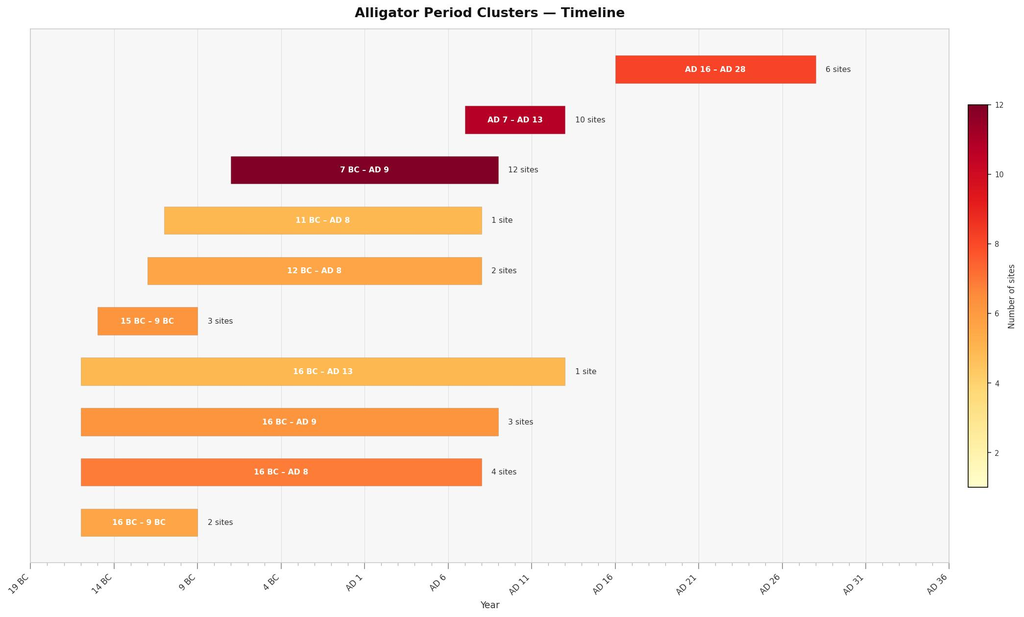

```python
plot_cluster_timeline(clusters, OUTPUT_DIR / "cluster_timeline.jpg")
from IPython.display import Image
Image(str(OUTPUT_DIR / "cluster_timeline.jpg"))
```

### 16.2 · Individual Events Timeline

```
✓ Events timeline saved: C:\git\CAA2026-alligator\output\events_timeline.jpg
```

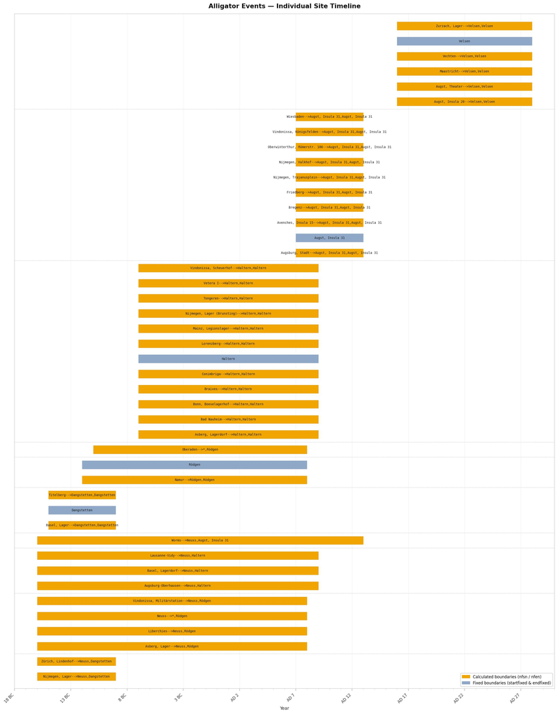

```python
plot_alligator_events_timeline(events, OUTPUT_DIR / "events_timeline.jpg")
Image(str(OUTPUT_DIR / "events_timeline.jpg"))
```

### 16.3 · Allen Relations Matrix

```
✓ Allen matrix saved: C:\git\CAA2026-alligator\output\allen_matrix.jpg
```

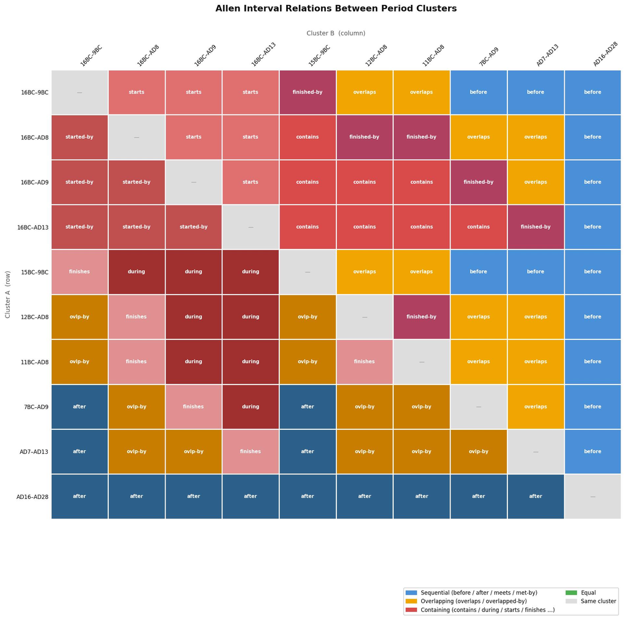

```python
plot_allen_relations_matrix(clusters, OUTPUT_DIR / "allen_matrix.jpg")
Image(str(OUTPUT_DIR / "allen_matrix.jpg"))
```

### 16.4 · Allen Chain (Nearest-Neighbour Graph)

```
✓ Allen chain saved: C:\git\CAA2026-alligator\output\allen_chain.jpg
```

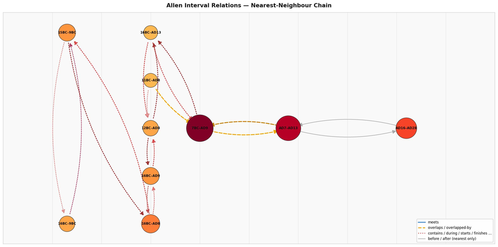

```python
plot_allen_chain(clusters, OUTPUT_DIR / "allen_chain.jpg")
Image(str(OUTPUT_DIR / "allen_chain.jpg"))
```

## 17 · Summary

All outputs written to `root/output/`:

| File | Description |
| --- | --- |
| `event_mapping.csv` | Label-to-event mapping table with match types |
| `findspots_with_events.csv` | Enriched findspot table with event properties |
| `arretine_sites_minigraph.ttl` | Full RDF graph (Turtle format) |
| `cluster_timeline.jpg` | Period cluster timeline visualisation |
| `events_timeline.jpg` | Individual Alligator events timeline |
| `allen_matrix.jpg` | Allen relations matrix |
| `allen_chain.jpg` | Allen nearest-neighbour chain graph |

```python
from datetime import datetime
print(f"Run complete: {datetime.now().strftime('%Y-%m-%d %H:%M:%S')}")
print(f"Output dir : {OUTPUT_DIR}")
for f in sorted(OUTPUT_DIR.iterdir()):
    size = f.stat().st_size
    print(f"  · {f.name:45s}  {size:>10,} bytes")
```

```
Run complete: 2026-03-17 12:51:13
Output dir : C:\git\CAA2026-alligator\output
  · allen_chain.jpg                                   131,644 bytes
  · allen_matrix.jpg                                  237,356 bytes
  · arretine_sites_minigraph.ttl                       68,611 bytes
  · cluster_timeline.jpg                              115,670 bytes
  · event_mapping.csv                                   7,226 bytes
  · events_timeline.jpg                               408,998 bytes
  · findspots_with_events.csv                           9,536 bytes
  · report.txt                                          3,605 bytes
```